# Diversidad y calidad de la oferta alimentaria en Sudamérica (FAO, 2010-2023): análisis descriptivo y elección de la siguiente etapa analítica

Juan Salazar y Luz Ríos

19 de octubre de 2026

```r
ruta <- file.path("data", "processed")  # relativo a la raíz del repo (ver scripts/render.R)
kpis   <- read_csv(file.path(ruta, "paises_definitivo_kpis.csv"),    show_col_types = FALSE) |> clean_names()
pca_cl <- read_csv(file.path(ruta, "paises_pca_clusters.csv"),       show_col_types = FALSE) |> clean_names()
panel  <- read_csv(file.path(ruta, "panel_pais_anio_definitivo.csv"), show_col_types = FALSE) |> clean_names()

# Según la versión de janitor, "Cluster_KMeans" puede quedar con distintos nombres
names(pca_cl) <- str_replace(names(pca_cl), "^cluster.*means$", "cluster_kmeans")

grupos <- c("aceites_vegetales", "almidon_de_raices", "carne", "cereales_exc_cerveza",
            "cultivos_azucareros", "frutas_excluso_vino", "grasas_animales", "hortalizas",
            "huevos", "leche_excl_mantequilla", "legumbres_secas", "nueces",
            "pescado_y_frutos_de_mar")

etiq_grupos <- c(aceites_vegetales = "Aceites vegetales", almidon_de_raices = "Almidón de raíces",
                 carne = "Carne", cereales_exc_cerveza = "Cereales",
                 cultivos_azucareros = "Cultivos azucareros", frutas_excluso_vino = "Frutas",
                 grasas_animales = "Grasas animales", hortalizas = "Hortalizas", huevos = "Huevos",
                 leche_excl_mantequilla = "Leche", legumbres_secas = "Legumbres secas",
                 nueces = "Nueces", pescado_y_frutos_de_mar = "Pescado y mariscos")

anios <- sort(unique(panel$ano))
```

# 1 Introducción

Este informe estudia la oferta alimentaria de 10 países de Sudamérica (Argentina, Bolivia, Brasil, Chile, Colombia, Ecuador, Paraguay, Perú, Uruguay y Venezuela) entre 2010 y 2023, a partir de datos de la FAO. El trabajo tiene dos propósitos: (i) construir una **base descriptiva** correcta y transparente sobre qué muestran estos datos y qué no, y (ii) a partir de esa base, **decidir con argumentos** si la siguiente etapa debe ser un análisis *diagnóstico* (explicar por qué ocurren las diferencias y los cambios) o uno *predictivo* (anticipar valores futuros), y con qué modelo.

**Pregunta general.** ¿Cómo se diferencian los países de la región en la diversidad, la cantidad de energía y nutrientes, y la calidad de su oferta alimentaria, y cómo ha cambiado esa oferta en el tiempo?

Las hipótesis del planteamiento original (asociación entre diversificación y disponibilidad de nutrientes) se reformulan aquí como **preguntas descriptivas**, que se responden con estadísticos y gráficos pero sin pretender confirmar causalidad:

- **P1.** ¿Qué países ofrecen más energía, proteína y grasa por persona, y cuán grande es la brecha entre ellos?
- **P2.** ¿Qué tan diversa es la oferta de cada país y cómo se relaciona la diversidad con los nutrientes y con el índice de calidad, tanto entre países como dentro de cada país a lo largo del tiempo?
- **P3.** ¿Cómo evolucionaron entre 2010 y 2023 la energía, la diversidad y los indicadores de comercio exterior (autosuficiencia, dependencia de importaciones, orientación exportadora)?
- **P4.** ¿Existen agrupaciones naturales de países según la estructura de su dieta?

Las pruebas que aparecen en el documento (correlaciones, tendencias, modelos de efectos fijos) se usan como **herramientas exploratorias**: con 10 países no pueden considerarse confirmatorias. La inferencia formal queda para la etapa que se elija en la sección final.

# 2 Datos

## 2.1 Fuente y alcance

Los indicadores provienen de FAOSTAT (FAO). Por su estructura (grupos de alimentos, producción, importaciones, exportaciones, suministro interno y kcal, proteína y grasa por persona y día) corresponden, con alta probabilidad, a las *Hojas de Balance de Alimentos* en su serie “Balances Alimentarios (2010-)”[^1]. Estos datos miden **disponibilidad** de alimentos en el país (lo que queda para consumo humano tras producción, comercio y otros usos), **no consumo real ni ingesta individual**, y no reflejan desigualdades de acceso ni desperdicio.

Se trabaja con tres archivos CSV derivados de esa fuente:

```r
tibble(
  archivo = c("paises_definitivo_kpis", "paises_pca_clusters", "panel_pais_anio_definitivo"),
  granularidad = c("1 fila por país", "1 fila por país", "1 fila por país y año"),
  filas = c(nrow(kpis), nrow(pca_cl), nrow(panel)),
  columnas = c(ncol(kpis), ncol(pca_cl), ncol(panel)),
  contenido = c("Indicadores agregados por país (ventana de años verificada en la sección 3)",
                "Los mismos indicadores más PC1, PC2 y un clúster (Cluster_KMeans) calculados previamente",
                "Serie anual con composición por grupo, energía, grasa, índices de calidad y comercio exterior")
) |> kable(caption = "Conjuntos de datos utilizados")
```

Conjuntos de datos utilizados

| archivo | granularidad | filas | columnas | contenido |
| --- | --- | --- | --- | --- |
| paises_definitivo_kpis | 1 fila por país | 10 | 23 | Indicadores agregados por país (ventana de años verificada en la sección 3) |
| paises_pca_clusters | 1 fila por país | 10 | 26 | Los mismos indicadores más PC1, PC2 y un clúster (Cluster_KMeans) calculados previamente |
| panel_pais_anio_definitivo | 1 fila por país y año | 140 | 31 | Serie anual con composición por grupo, energía, grasa, índices de calidad y comercio exterior |

## 2.2 Diccionario de variables

```r
dic <- tribble(
  ~variable, ~dataset, ~definicion,
  "13 grupos de alimentos (aceites vegetales, almidón de raíces, carne, cereales, cultivos azucareros, frutas, grasas animales, hortalizas, huevos, leche, legumbres secas, nueces, pescado y mariscos)", "KPIs, PCA, panel", "Suministro por grupo de alimentos. Unidad probable: gramos por persona y día (a confirmar con la ficha de descarga).",
  "food_diversity_index", "KPIs, PCA, panel", "Índice de Shannon (logaritmo natural) sobre la distribución del suministro entre los 13 grupos: H = -sum(p_i ln p_i). Máximo teórico ln(13). Se verifica en la sección 3.",
  "kcal_persona_dia_total / kcal_dia_total", "KPIs, PCA / panel", "Energía disponible por persona y día.",
  "proteina_g_persona_dia_total", "KPIs, PCA", "Proteína disponible (g por persona y día). **No existe en el panel**: la proteína solo puede analizarse a nivel país.",
  "grasa_g_persona_dia_total / grasa_g_dia_total", "KPIs, PCA / panel", "Grasa disponible (g por persona y día).",
  "frutas_hortalizas_g_dia", "KPIs, PCA, panel", "Frutas y hortalizas disponibles (g por persona y día).",
  "pct_energia_grasa", "KPIs, PCA, panel", "Porcentaje de la energía que proviene de grasa: grasa (g) x 9 / kcal x 100.",
  "score_frutas_verduras", "KPIs, PCA, panel", "100 x (g/día de frutas y hortalizas / 400), truncado en 100 (referencia OMS: al menos 400 g/día).",
  "score_grasa", "KPIs, PCA, panel", "100 si la grasa aporta hasta 30 % de la energía; resta 5 puntos por cada punto porcentual por encima de 30 % (referencia OMS: menos de 30 %).",
  "indice_calidad_oferta(_parcial)", "KPIs, PCA / panel", "Promedio de score_frutas_verduras y score_grasa. Es **parcial**: no incorpora proteína, azúcares, sodio ni micronutrientes.",
  "produccion_total, importaciones_total, exportaciones_total, suministro_interno_total", "panel", "Volúmenes físicos (no valor monetario), en las unidades del archivo original.",
  "ratio_autosuficiencia", "panel", "Producción / suministro interno (1 = autosuficiencia plena).",
  "ratio_dependencia_importaciones", "panel", "Importaciones / suministro interno.",
  "ratio_orientacion_exportadora", "panel", "Exportaciones / producción.",
  "pc1, pc2, cluster_kmeans", "PCA", "Coordenadas de los dos primeros componentes y clúster asignado por el análisis previo (su reproducibilidad se evalúa en la sección 8).",
  "cluster", "panel", "Clúster por país-año del panel. **Se excluye del análisis** (motivo en la sección 3)."
)
kable(dic, col.names = c("Variable", "Dataset", "Definición"), caption = "Diccionario de variables")
```

Diccionario de variables

| Variable | Dataset | Definición |
| --- | --- | --- |
| 13 grupos de alimentos (aceites vegetales, almidón de raíces, carne, cereales, cultivos azucareros, frutas, grasas animales, hortalizas, huevos, leche, legumbres secas, nueces, pescado y mariscos) | KPIs, PCA, panel | Suministro por grupo de alimentos. Unidad probable: gramos por persona y día (a confirmar con la ficha de descarga). |
| food_diversity_index | KPIs, PCA, panel | Índice de Shannon (logaritmo natural) sobre la distribución del suministro entre los 13 grupos: H = -sum(p_i ln p_i). Máximo teórico ln(13). Se verifica en la sección 3. |
| kcal_persona_dia_total / kcal_dia_total | KPIs, PCA / panel | Energía disponible por persona y día. |
| proteina_g_persona_dia_total | KPIs, PCA | Proteína disponible (g por persona y día). **No existe en el panel**: la proteína solo puede analizarse a nivel país. |
| grasa_g_persona_dia_total / grasa_g_dia_total | KPIs, PCA / panel | Grasa disponible (g por persona y día). |
| frutas_hortalizas_g_dia | KPIs, PCA, panel | Frutas y hortalizas disponibles (g por persona y día). |
| pct_energia_grasa | KPIs, PCA, panel | Porcentaje de la energía que proviene de grasa: grasa (g) x 9 / kcal x 100. |
| score_frutas_verduras | KPIs, PCA, panel | 100 x (g/día de frutas y hortalizas / 400), truncado en 100 (referencia OMS: al menos 400 g/día). |
| score_grasa | KPIs, PCA, panel | 100 si la grasa aporta hasta 30 % de la energía; resta 5 puntos por cada punto porcentual por encima de 30 % (referencia OMS: menos de 30 %). |
| indice_calidad_oferta(_parcial) | KPIs, PCA / panel | Promedio de score_frutas_verduras y score_grasa. Es **parcial**: no incorpora proteína, azúcares, sodio ni micronutrientes. |
| produccion_total, importaciones_total, exportaciones_total, suministro_interno_total | panel | Volúmenes físicos (no valor monetario), en las unidades del archivo original. |
| ratio_autosuficiencia | panel | Producción / suministro interno (1 = autosuficiencia plena). |
| ratio_dependencia_importaciones | panel | Importaciones / suministro interno. |
| ratio_orientacion_exportadora | panel | Exportaciones / producción. |
| pc1, pc2, cluster_kmeans | PCA | Coordenadas de los dos primeros componentes y clúster asignado por el análisis previo (su reproducibilidad se evalúa en la sección 8). |
| cluster | panel | Clúster por país-año del panel. **Se excluye del análisis** (motivo en la sección 3). |

# 3 Calidad y consistencia de los datos

Todos los controles de esta sección se calculan al compilar el documento; el estado que se informa (*Cumple* / *No cumple*) proviene de la comparación numérica, no de una afirmación fija.

```r
shannon <- function(x) { p <- x / sum(x); p <- p[p > 0]; -sum(p * log(p)) }

# --- Valores faltantes, duplicados y estructura del panel
na_tot <- c(kpis = sum(is.na(kpis)), pca = sum(is.na(pca_cl)), panel = sum(is.na(panel)))
dup_tot <- c(kpis = sum(duplicated(kpis)), pca = sum(duplicated(pca_cl)),
             panel = sum(duplicated(panel[, c("pais", "ano")])))
n_paises <- n_distinct(panel$pais)
panel_completo <- nrow(panel) == n_paises * length(anios) &&
  all(count(panel, pais)$n == length(anios))
mismos_paises <- setequal(kpis$pais, panel$pais) && setequal(kpis$pais, pca_cl$pais)
mismo_orden <- identical(kpis$pais, pca_cl$pais)

# --- Ventana de años a la que corresponden los KPIs (se prueban todas las ventanas consecutivas)
ventanas <- expand_grid(largo = 1:length(anios), inicio = anios) |>
  filter(inicio + largo - 1 <= max(anios)) |>
  mutate(max_dif_kcal = map2_dbl(inicio, largo, function(a0, l) {
    v <- panel |>
      filter(ano >= a0, ano <= a0 + l - 1) |>
      group_by(pais) |>
      summarise(k = mean(kcal_dia_total), .groups = "drop") |>
      left_join(select(kpis, pais, kcal_persona_dia_total), by = "pais")
    max(abs(v$k - v$kcal_persona_dia_total))
  }))
vent_mejor <- slice_min(ventanas, max_dif_kcal, n = 1, with_ties = FALSE)
vent_ok <- vent_mejor$max_dif_kcal < 0.01
v_ini <- if (vent_ok) vent_mejor$inicio else 2019
v_fin <- if (vent_ok) vent_mejor$inicio + vent_mejor$largo - 1 else max(anios)
vent_txt <- paste0(v_ini, "-", v_fin)
vent_es_completa <- v_ini == min(anios) && v_fin == max(anios)

panel_vent <- filter(panel, ano >= v_ini, ano <= v_fin)

# --- Composición por grupo: KPIs frente al promedio de la ventana
comp_vent <- panel_vent |> group_by(pais) |> summarise(across(all_of(grupos), mean), .groups = "drop") |>
  arrange(match(pais, kpis$pais))
dif_grupos <- map_dfr(grupos, function(g) {
  d <- abs(comp_vent[[g]] - kpis[[g]])
  tibble(grupo = g, max_dif = max(d), pais = kpis$pais[which.max(d)])
})
grupos_dif <- filter(dif_grupos, max_dif > 1e-6)

# --- Índice de diversidad: definición y reconciliación
panel_sh <- panel |> rowwise() |> mutate(sh = shannon(c_across(all_of(grupos)))) |> ungroup()
dif_div_panel <- max(abs(panel_sh$sh - panel_sh$food_diversity_index))
dif_div_kpis  <- max(abs(apply(kpis[grupos], 1, shannon) - kpis$food_diversity_index))
div_media_anual <- panel_vent |> group_by(pais) |> summarise(d = mean(food_diversity_index), .groups = "drop") |>
  arrange(match(pais, kpis$pais))
dif_div_media <- max(abs(div_media_anual$d - kpis$food_diversity_index))
dif_div_compvent <- max(abs(apply(comp_vent[grupos], 1, shannon) - kpis$food_diversity_index))
rho_div <- cor(div_media_anual$d, kpis$food_diversity_index, method = "spearman")
ln13 <- log(length(grupos))

# --- Ratios comerciales e índices derivados
dif_aut <- max(abs(panel$produccion_total / panel$suministro_interno_total - panel$ratio_autosuficiencia))
dif_dep <- max(abs(panel$importaciones_total / panel$suministro_interno_total - panel$ratio_dependencia_importaciones))
dif_exp <- max(abs(panel$exportaciones_total / panel$produccion_total - panel$ratio_orientacion_exportadora))
dif_pg  <- max(abs(kpis$grasa_g_persona_dia_total * 9 / kpis$kcal_persona_dia_total * 100 - kpis$pct_energia_grasa))
dif_fv  <- max(abs(pmin(100, 100 * kpis$frutas_hortalizas_g_dia / 400) - kpis$score_frutas_verduras))
dif_sg  <- max(abs(pmax(0, pmin(100, 100 - 5 * (kpis$pct_energia_grasa - 30))) - kpis$score_grasa))
dif_q   <- max(abs((kpis$score_frutas_verduras + kpis$score_grasa) / 2 - kpis$indice_calidad_oferta_parcial))

# --- Clúster del panel frente a Cluster_KMeans
cl_cmp <- panel |> group_by(pais) |>
  summarise(valores_panel = n_distinct(cluster), difiere_alguna_vez = NA, .groups = "drop") |>
  left_join(select(pca_cl, pais, cluster_kmeans), by = "pais")
cl_cmp$difiere_alguna_vez <- map_lgl(cl_cmp$pais, function(p)
  any(panel$cluster[panel$pais == p] != cl_cmp$cluster_kmeans[cl_cmp$pais == p]))
n_cl_difieren <- sum(cl_cmp$difiere_alguna_vez)
cl_cambian <- cl_cmp$pais[cl_cmp$valores_panel > 1]
cl_difieren <- cl_cmp$pais[cl_cmp$difiere_alguna_vez]
```

```r
estado <- function(ok) ifelse(ok, "Cumple", "No cumple")
ctrl <- tibble(
  control = c("Valores faltantes en los tres datasets",
              "Filas duplicadas (KPIs, PCA; claves país-año en el panel)",
              "Panel completo: 10 países x 14 años = 140 filas",
              "Mismos 10 países en los tres datasets",
              "Mismo orden de países en KPIs y PCA",
              paste0("Los KPIs de energía coinciden con el promedio de una ventana de años del panel (", vent_txt, ")"),
              "Composición por grupo de los KPIs = promedio de esa ventana (tolerancia 1e-6)",
              "Índice de diversidad del panel = Shannon sobre los 13 grupos (tolerancia 1e-9)",
              "Índice de diversidad de los KPIs = Shannon sobre la composición de los KPIs (tolerancia 1e-9)",
              "Índice de diversidad de los KPIs = promedio anual del índice del panel en la ventana (tolerancia 1e-3)",
              "Ratios comerciales responden a sus definiciones (tolerancia 0.01)",
              "Indicadores de calidad se reproducen desde las variables básicas (tolerancia 0.15)",
              "Clúster del panel coincide con Cluster_KMeans"),
  resultado = c(paste(sum(na_tot), "valores faltantes"),
                paste(sum(dup_tot), "duplicados"),
                paste0(nrow(panel), " filas; ", n_paises, " países; ", length(anios), " años"),
                ifelse(mismos_paises, "Coinciden", "Difieren"),
                ifelse(mismo_orden, "Mismo orden", "Distinto orden"),
                paste0("Dif. máx. = ", formatC(vent_mejor$max_dif_kcal, format = "e", digits = 1), " kcal"),
                paste0(ifelse(nrow(grupos_dif) == 0, "Todos los grupos coinciden",
                              paste0(nrow(grupos_dif), " grupo(s) difieren: ", paste(etiq_grupos[grupos_dif$grupo], collapse = ", "))),
                       "; dif. máx. = ", f2(max(dif_grupos$max_dif), 3)),
                paste0("Dif. máx. = ", formatC(dif_div_panel, format = "e", digits = 1)),
                paste0("Dif. máx. = ", formatC(dif_div_kpis, format = "e", digits = 1)),
                paste0("Dif. máx. = ", f2(dif_div_media, 4)),
                paste0("Dif. máx. = ", formatC(max(dif_aut, dif_dep, dif_exp), format = "e", digits = 1)),
                paste0("Dif. máx. = ", f2(max(dif_pg, dif_fv, dif_sg, dif_q), 3)),
                paste0(n_cl_difieren, " de ", n_paises, " países difieren en algún año")),
  estado = estado(c(sum(na_tot) == 0, sum(dup_tot) == 0, panel_completo, mismos_paises, mismo_orden,
                    vent_ok, nrow(grupos_dif) == 0, dif_div_panel < 1e-9, dif_div_kpis < 1e-9,
                    dif_div_media < 1e-3, max(dif_aut, dif_dep, dif_exp) < 0.01,
                    max(dif_pg, dif_fv, dif_sg, dif_q) < 0.15, n_cl_difieren == 0))
)
kable(ctrl, col.names = c("Control", "Resultado", "Estado"), caption = "Controles automáticos de calidad y consistencia")
```

Controles automáticos de calidad y consistencia

| Control | Resultado | Estado |
| --- | --- | --- |
| Valores faltantes en los tres datasets | 0 valores faltantes | Cumple |
| Filas duplicadas (KPIs, PCA; claves país-año en el panel) | 0 duplicados | Cumple |
| Panel completo: 10 países x 14 años = 140 filas | 140 filas; 10 países; 14 años | Cumple |
| Mismos 10 países en los tres datasets | Coinciden | Cumple |
| Mismo orden de países en KPIs y PCA | Mismo orden | Cumple |
| Los KPIs de energía coinciden con el promedio de una ventana de años del panel (2019-2023) | Dif. máx. = 4.5e-13 kcal | Cumple |
| Composición por grupo de los KPIs = promedio de esa ventana (tolerancia 1e-6) | 1 grupo(s) difieren: Cultivos azucareros; dif. máx. = 0.331 | No cumple |
| Índice de diversidad del panel = Shannon sobre los 13 grupos (tolerancia 1e-9) | Dif. máx. = 8.9e-16 | Cumple |
| Índice de diversidad de los KPIs = Shannon sobre la composición de los KPIs (tolerancia 1e-9) | Dif. máx. = 2.2e-16 | Cumple |
| Índice de diversidad de los KPIs = promedio anual del índice del panel en la ventana (tolerancia 1e-3) | Dif. máx. = 0.0055 | No cumple |
| Ratios comerciales responden a sus definiciones (tolerancia 0.01) | Dif. máx. = 4.4e-16 | Cumple |
| Indicadores de calidad se reproducen desde las variables básicas (tolerancia 0.15) | Dif. máx. = 0.050 | Cumple |
| Clúster del panel coincide con Cluster_KMeans | 7 de 10 países difieren en algún año | No cumple |

## 3.1 Hallazgos de consistencia

**Ventana temporal de los KPIs.** Los KPIs por país no resumen los 14 años del panel: sus kcal coinciden con el promedio de **2019-2023** (5 años; diferencia máxima 4.5e-13 kcal). En consecuencia, **todos los resultados a nivel de país (secciones 4.1, 5, 7.1, 7.2 y 8) describen 2019-2023**, mientras que las secciones de evolución usan 2010-2023. Cuando se comparan países con indicadores del panel (razones comerciales), se usa la misma ventana.

**Composición por grupo.** La composición de los KPIs coincide con el promedio de la ventana en 12 de 13 grupos; Cultivos azucareros difiere (diferencia máxima 0.33, en Uruguay). Es una discrepancia menor que se documenta y no altera las conclusiones.

**Índice de diversidad.** El índice del panel se reproduce exactamente como un índice de Shannon calculado año a año sobre los 13 grupos (diferencia máxima 8.9e-16). El índice de los KPIs se reproduce, con la misma exactitud (2.2e-16), como el Shannon de la **composición promedio** del país, no como el promedio de los índices anuales: ambas versiones difieren hasta 0.0055 y, como Shannon es cóncavo, la segunda es siempre menor o igual que la primera. La ordenación de los países es casi idéntica (correlación de Spearman entre ambas versiones = 0.988). **Criterio adoptado:** en las comparaciones entre países (ventana 2019-2023) se usa el índice de los KPIs; en las series temporales y en los modelos de panel, el índice anual del panel. El máximo teórico con 13 grupos es ln(13) = 2.565.

**Clúster del panel (excluido).** La columna `cluster` del panel no coincide con `Cluster_KMeans` del archivo de PCA: 7 de 10 países difieren en al menos un año (Bolivia, Chile, Colombia, Ecuador, Paraguay, Perú, Venezuela), y Venezuela cambia de clúster según el año. Una asignación que cambia con el año y contradice la del archivo país-nivel no tiene una definición única, por lo que **se excluye `cluster` del panel** y se usa solamente la partición de `paises_pca_clusters`, evaluada de forma crítica en la sección 8.

**Proteína.** El panel no contiene proteína: las comparaciones de proteína son solo entre países (n = 10), no existe análisis temporal de proteína.

## 3.2 Ceros estructurales

```r
ceros <- map_dfr(grupos, function(g) tibble(grupo = etiq_grupos[g], paises_con_cero = sum(kpis[[g]] == 0),
                                            maximo = max(kpis[[g]]), pais_maximo = kpis$pais[which.max(kpis[[g]])])) |>
  filter(paises_con_cero > 0)
az_cero <- ceros$paises_con_cero[ceros$grupo == "Cultivos azucareros"]
kable(ceros, digits = 2, caption = "Grupos con valor cero a nivel de país (KPIs)")
```

Grupos con valor cero a nivel de país (KPIs)

| grupo | paises_con_cero | maximo | pais_maximo |
| --- | --- | --- | --- |
| Cultivos azucareros | 5 | 15.85 | Brasil |

Cultivos azucareros es cero en 5 de 10 países y alcanza 15.9 en Brasil. Los ceros son estructurales (el grupo no se registra como suministro de ese país) y no se interpretan como datos ausentes; su asimetría refleja una característica real de la oferta.

## 3.3 Valores atípicos

Un criterio de rango intercuartílico (IQR) aplicado al panel completo mezclado confunde **escala** (países grandes) con **comportamiento anómalo**. Por eso se comparan dos detecciones: la *mezclada* (140 filas juntas) y la *intra-país* (cada país contra su propia serie).

```r
es_atipico <- function(x) { q <- quantile(x, c(.25, .75)); i <- diff(q); x < q[1] - 1.5 * i | x > q[2] + 1.5 * i }
vars_out <- c("produccion_total", "importaciones_total", "exportaciones_total",
              "suministro_interno_total", "kcal_dia_total", "food_diversity_index", "indice_calidad_oferta")

out_mezclado <- map_int(vars_out, ~ sum(es_atipico(panel[[.x]])))
out_intra <- map_dfr(vars_out, function(v) {
  panel |> group_by(pais) |> filter(es_atipico(.data[[v]])) |> ungroup() |>
    transmute(variable = v, pais, ano, valor = .data[[v]])
})
tab_out <- tibble(variable = vars_out, atipicos_mezclado = out_mezclado,
                  atipicos_intra_pais = map_int(vars_out, ~ sum(out_intra$variable == .x)))
kable(tab_out, caption = "Observaciones atípicas según el método de detección (IQR)")
```

Observaciones atípicas según el método de detección (IQR)

| variable | atipicos_mezclado | atipicos_intra_pais |
| --- | --- | --- |
| produccion_total | 18 | 7 |
| importaciones_total | 8 | 5 |
| exportaciones_total | 28 | 4 |
| suministro_interno_total | 14 | 1 |
| kcal_dia_total | 0 | 2 |
| food_diversity_index | 7 | 3 |
| indice_calidad_oferta | 9 | 1 |

```r
out_intra |> arrange(variable, pais, ano) |>
  kable(digits = 1, caption = "Observaciones atípicas dentro de la serie de su propio país")
```

Observaciones atípicas dentro de la serie de su propio país

| variable | pais | ano | valor |
| --- | --- | --- | --- |
| exportaciones_total | Brasil | 2023 | 86240.0 |
| exportaciones_total | Venezuela | 2021 | 76.0 |
| exportaciones_total | Venezuela | 2022 | 80.0 |
| exportaciones_total | Venezuela | 2023 | 144.0 |
| food_diversity_index | Brasil | 2010 | 2.1 |
| food_diversity_index | Brasil | 2011 | 2.1 |
| food_diversity_index | Chile | 2020 | 2.0 |
| importaciones_total | Argentina | 2015 | 1436.0 |
| importaciones_total | Argentina | 2017 | 2125.0 |
| importaciones_total | Argentina | 2023 | 1419.0 |
| importaciones_total | Brasil | 2015 | 15549.0 |
| importaciones_total | Brasil | 2016 | 23662.0 |
| indice_calidad_oferta | Colombia | 2021 | 97.8 |
| kcal_dia_total | Colombia | 2010 | 2801.4 |
| kcal_dia_total | Colombia | 2011 | 2804.0 |
| produccion_total | Brasil | 2023 | 1106885.0 |
| produccion_total | Chile | 2011 | 24647.0 |
| produccion_total | Chile | 2018 | 24404.0 |
| produccion_total | Ecuador | 2013 | 23119.0 |
| produccion_total | Ecuador | 2015 | 28321.0 |
| produccion_total | Ecuador | 2020 | 27246.0 |
| produccion_total | Ecuador | 2021 | 29031.0 |
| suministro_interno_total | Brasil | 2023 | 1034250.0 |

Con detección mezclada, `exportaciones_total` marca 28 observaciones, que en su mayoría son los años completos de los países de mayor tamaño: es escala, no error. Con detección intra-país quedan 4. Dos casos merecen atención y se desarrollan en la sección 6:

- **Venezuela.** Sus exportaciones **aumentan** de forma abrupta: entre 2010 y 2020 oscilaron entre 15 y 43 (unidades del panel), y en 2021, 2022 y 2023 fueron 76, 80 y 144. La detección intra-país señala 2021, 2022, 2023 como atípicos.
- **Brasil 2023.** Sus exportaciones (86 240) superan el máximo de todos los años anteriores (74 773); la detección intra-país lo marca como atípico.

**Tratamiento.** No se eliminan ni se imputan filas: no hay evidencia de error de captura, y descartar a los países grandes eliminaría justamente la variabilidad que se quiere describir. Se emplean razones normalizadas por tamaño (autosuficiencia, dependencia, orientación exportadora), estadísticos robustos (mediana, IQR) y gráficos por país.

# 4 Análisis descriptivo univariado

```r
resumen <- function(df, vars, etiquetas = vars) {
  df |> select(all_of(vars)) |> pivot_longer(everything(), names_to = "variable", values_to = "x") |>
    group_by(variable) |>
    summarise(n = n(), media = mean(x), mediana = median(x), de = sd(x), cv = sd(x) / mean(x),
              minimo = min(x), maximo = max(x), iqr = IQR(x),
              asimetria = skewness(x), curtosis = kurtosis(x), .groups = "drop") |>
    mutate(variable = etiquetas[match(variable, vars)]) |>
    arrange(match(variable, etiquetas))
}
```

## 4.1 Nivel país (ventana 2019-2023, n = 10)

```r
vars_k <- c("food_diversity_index", "kcal_persona_dia_total", "proteina_g_persona_dia_total",
            "grasa_g_persona_dia_total", "pct_energia_grasa", "frutas_hortalizas_g_dia",
            "indice_calidad_oferta_parcial")
et_k <- c("Índice de diversidad", "Energía (kcal/día)", "Proteína (g/día)", "Grasa (g/día)",
          "Energía de grasa (%)", "Frutas y hortalizas (g/día)", "Índice de calidad parcial")
u_k <- resumen(kpis, vars_k, et_k)
kable(u_k, digits = 2, caption = "Estadísticos descriptivos por país (curtosis: normal = 3)")
```

Estadísticos descriptivos por país (curtosis: normal = 3)

| variable | n | media | mediana | de | cv | minimo | maximo | iqr | asimetria | curtosis |
| --- | --- | --- | --- | --- | --- | --- | --- | --- | --- | --- |
| Índice de diversidad | 10 | 1.96 | 1.95 | 0.06 | 0.03 | 1.88 | 2.09 | 0.06 | 0.81 | 3.27 |
| Energía (kcal/día) | 10 | 2962.36 | 3085.64 | 358.58 | 0.12 | 2394.08 | 3378.09 | 626.13 | -0.41 | 1.69 |
| Proteína (g/día) | 10 | 89.07 | 85.86 | 17.58 | 0.20 | 66.91 | 118.92 | 28.56 | 0.25 | 1.82 |
| Grasa (g/día) | 10 | 99.86 | 97.43 | 26.11 | 0.26 | 58.67 | 139.32 | 26.91 | 0.04 | 2.12 |
| Energía de grasa (%) | 10 | 30.06 | 30.55 | 5.58 | 0.19 | 21.40 | 37.10 | 7.53 | -0.30 | 1.86 |
| Frutas y hortalizas (g/día) | 10 | 422.90 | 420.83 | 95.54 | 0.23 | 232.94 | 543.47 | 121.75 | -0.39 | 2.71 |
| Índice de calidad parcial | 10 | 91.21 | 93.95 | 10.83 | 0.12 | 66.40 | 100.00 | 13.50 | -1.28 | 3.67 |

Con solo 10 observaciones, las medidas de forma son inestables y se leen como descriptivas. El índice de diversidad varía entre 1.88 y 2.09 (coeficiente de variación 2.9 %), es decir, una dispersión pequeña comparada con la energía (12.1 %) o la proteína (19.7 %). Entre los grupos de alimentos, los más asimétricos son Cultivos azucareros (2.64), Nueces (1.97), Pescado y mariscos (1.62). 6 de 10 países alcanzan el techo de 100 en `score_frutas_verduras`, lo que produce asimetría negativa y efecto techo en el índice de calidad.

## 4.2 Serie país-año (n = 140)

```r
vars_p <- c("food_diversity_index", "kcal_dia_total", "grasa_g_dia_total", "indice_calidad_oferta",
            "ratio_autosuficiencia", "ratio_dependencia_importaciones", "ratio_orientacion_exportadora",
            "produccion_total", "exportaciones_total")
et_p <- c("Índice de diversidad", "Energía (kcal/día)", "Grasa (g/día)", "Índice de calidad",
          "Autosuficiencia", "Dependencia de importaciones", "Orientación exportadora",
          "Producción total", "Exportaciones totales")
u_p <- resumen(panel, vars_p, et_p)

pct_entre <- map_dbl(vars_p, function(v) {
  a <- anova(lm(panel[[v]] ~ factor(panel$pais)))
  100 * a$`Sum Sq`[1] / sum(a$`Sum Sq`)
})
u_p$pct_variab_entre_paises <- pct_entre
kable(u_p, digits = 2, caption = "Estadísticos descriptivos del panel (última columna: % de la variabilidad total que corresponde a diferencias entre países)")
```

Estadísticos descriptivos del panel (última columna: % de la variabilidad total que corresponde a diferencias entre países)

| variable | n | media | mediana | de | cv | minimo | maximo | iqr | asimetria | curtosis | pct_variab_entre_paises |
| --- | --- | --- | --- | --- | --- | --- | --- | --- | --- | --- | --- |
| Índice de diversidad | 140 | 1.95 | 1.94 | 0.06 | 0.03 | 1.84 | 2.09 | 0.07 | 0.79 | 3.49 | 88.74 |
| Energía (kcal/día) | 140 | 2915.48 | 3015.98 | 333.67 | 0.11 | 2189.77 | 3423.45 | 539.04 | -0.53 | 2.17 | 88.74 |
| Grasa (g/día) | 140 | 94.98 | 97.34 | 22.74 | 0.24 | 53.39 | 141.98 | 25.93 | -0.12 | 2.38 | 88.52 |
| Índice de calidad | 140 | 92.90 | 96.12 | 8.90 | 0.10 | 60.87 | 100.00 | 10.41 | -1.67 | 5.45 | 72.42 |
| Autosuficiencia | 140 | 1.15 | 1.04 | 0.27 | 0.23 | 0.71 | 1.87 | 0.35 | 0.63 | 2.78 | 94.53 |
| Dependencia de importaciones | 140 | 0.14 | 0.12 | 0.12 | 0.80 | 0.02 | 0.44 | 0.19 | 0.64 | 2.32 | 92.61 |
| Orientación exportadora | 140 | 0.22 | 0.21 | 0.18 | 0.80 | 0.00 | 0.62 | 0.31 | 0.31 | 1.83 | 96.26 |
| Producción total | 140 | 135689.32 | 24041.00 | 294865.08 | 2.17 | 6725.00 | 1106885.00 | 50017.50 | 2.61 | 7.96 | 99.79 |
| Exportaciones totales | 140 | 14125.72 | 6167.00 | 20068.46 | 1.42 | 15.00 | 86240.00 | 6007.25 | 1.76 | 4.82 | 91.37 |

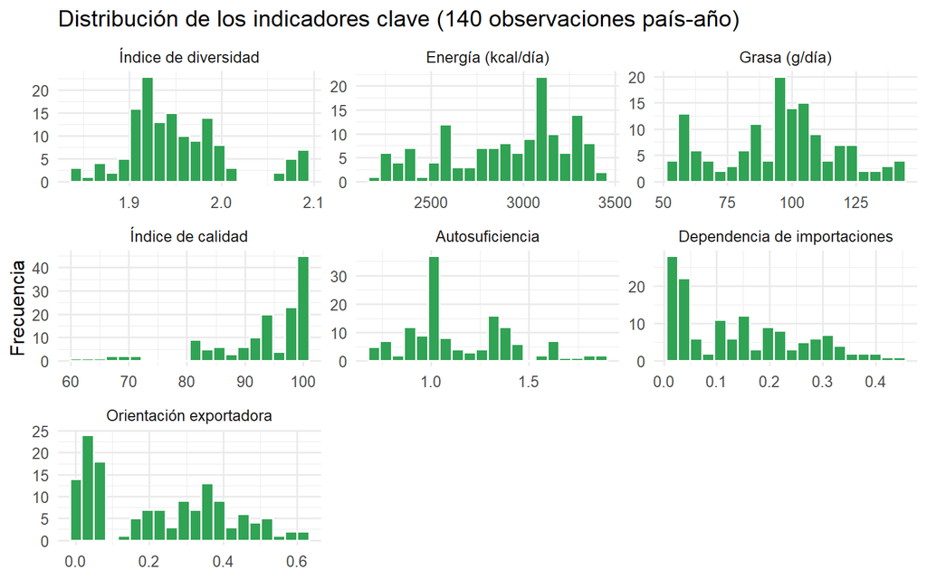

```r
panel |> select(all_of(vars_p[1:7])) |>
  pivot_longer(everything(), names_to = "variable", values_to = "valor") |>
  mutate(variable = factor(variable, levels = vars_p, labels = et_p)) |>
  ggplot(aes(valor)) +
  geom_histogram(bins = 20, fill = "#31a354", color = "white") +
  facet_wrap(~variable, scales = "free", ncol = 3) +
  labs(title = "Distribución de los indicadores clave (140 observaciones país-año)", x = NULL, y = "Frecuencia")
```

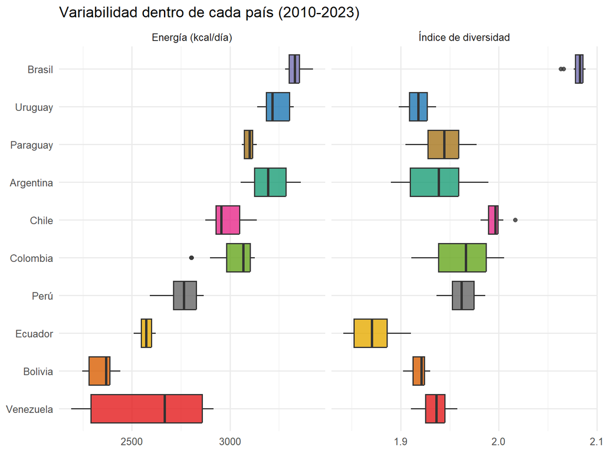

```r
panel |> select(pais, ano, kcal_dia_total, food_diversity_index) |>
  pivot_longer(c(kcal_dia_total, food_diversity_index)) |>
  mutate(name = recode(name, kcal_dia_total = "Energía (kcal/día)", food_diversity_index = "Índice de diversidad")) |>
  ggplot(aes(fct_reorder(pais, value, median), value, fill = pais)) +
  geom_boxplot(show.legend = FALSE, alpha = 0.8) +
  scale_fill_manual(values = paleta_paises) +
  coord_flip() + facet_wrap(~name, scales = "free_x") +
  labs(title = "Variabilidad dentro de cada país (2010-2023)", x = NULL, y = NULL)
```

En el panel, 89 % de la variabilidad del índice de diversidad y 89 % de la de la energía corresponden a diferencias entre países; el resto es variación dentro de cada país a lo largo del tiempo. La diversidad es, por tanto, sobre todo un rasgo permanente de cada país. Las variables de volumen (producción y exportaciones) tienen asimetrías de 2.61 y 1.76, consecuencia de la diferencia de tamaño entre países y no de errores de medición.

# 5 Comparación entre países (ventana 2019-2023)

## 5.1 Ranking de indicadores

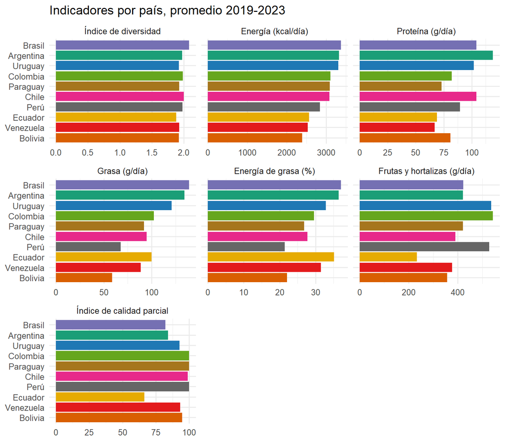

```r
orden_pais <- kpis |> arrange(desc(kcal_persona_dia_total)) |> pull(pais)
kpis |>
  select(pais, all_of(vars_k)) |>
  pivot_longer(-pais, names_to = "variable", values_to = "valor") |>
  mutate(variable = factor(variable, levels = vars_k, labels = et_k)) |>
  ggplot(aes(fct_rev(factor(pais, levels = orden_pais)), valor, fill = pais)) +
  geom_col(show.legend = FALSE) +
  scale_fill_manual(values = paleta_paises) +
  coord_flip() + facet_wrap(~variable, scales = "free_x", ncol = 3) +
  labs(title = paste0("Indicadores por país, promedio ", vent_txt), x = NULL, y = NULL)
```

- **Energía.** Va de 2 394 kcal/día en Bolivia a 3 378 en Brasil (41 % de brecha). Venezuela (2 530 kcal/día) se ubica en el extremo bajo del grupo, junto con Bolivia y Ecuador; su caída reciente se describe en la sección 6.
- **Proteína.** Máxima en Argentina (118.9 g/día) y mínima en Venezuela (66.9 g/día).
- **Diversidad.** Brasil ocupa el primer lugar (2.09, 2.2 desviaciones estándar sobre la media) y Ecuador el último (1.88). Los otros nueve países están entre 1.88 y 2.00: más allá del primero, las diferencias de diversidad son muy pequeñas. Todos los países están entre el 73 % y el 81 % del máximo teórico (ln 13 = 2.56).
- **Calidad parcial.** El valor más alto es 100.0 (Colombia) y el más bajo 66.4 (Ecuador).

## 5.2 Perfil de la dieta y de la calidad

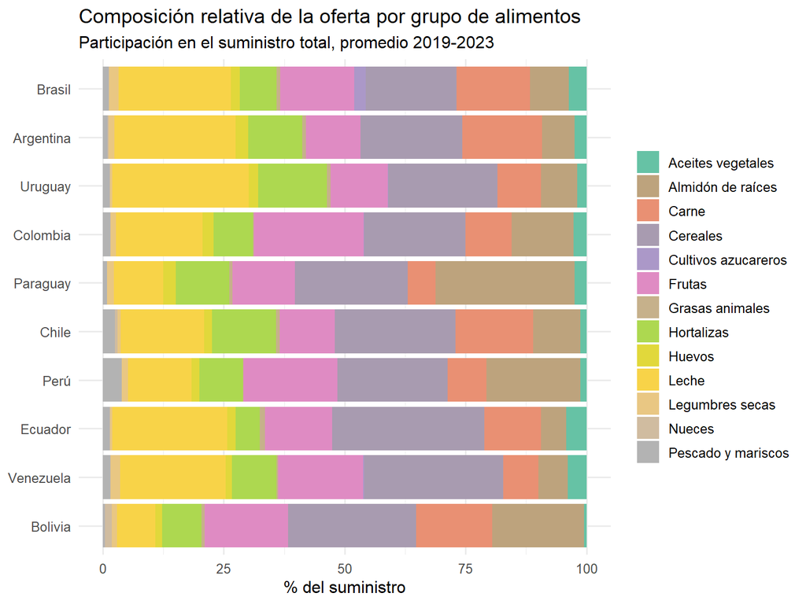

```r
comp_long <- kpis |> select(pais, all_of(grupos)) |>
  pivot_longer(-pais, names_to = "grupo", values_to = "valor") |>
  group_by(pais) |> mutate(pct = 100 * valor / sum(valor)) |> ungroup() |>
  mutate(grupo = etiq_grupos[grupo])

ggplot(comp_long, aes(factor(pais, levels = rev(orden_pais)), pct, fill = grupo)) +
  geom_col() + coord_flip() +
  scale_fill_manual(values = colorRampPalette(RColorBrewer::brewer.pal(8, "Set2"))(13), name = NULL) +
  labs(title = "Composición relativa de la oferta por grupo de alimentos",
       subtitle = paste0("Participación en el suministro total, promedio ", vent_txt),
       x = NULL, y = "% del suministro")
```

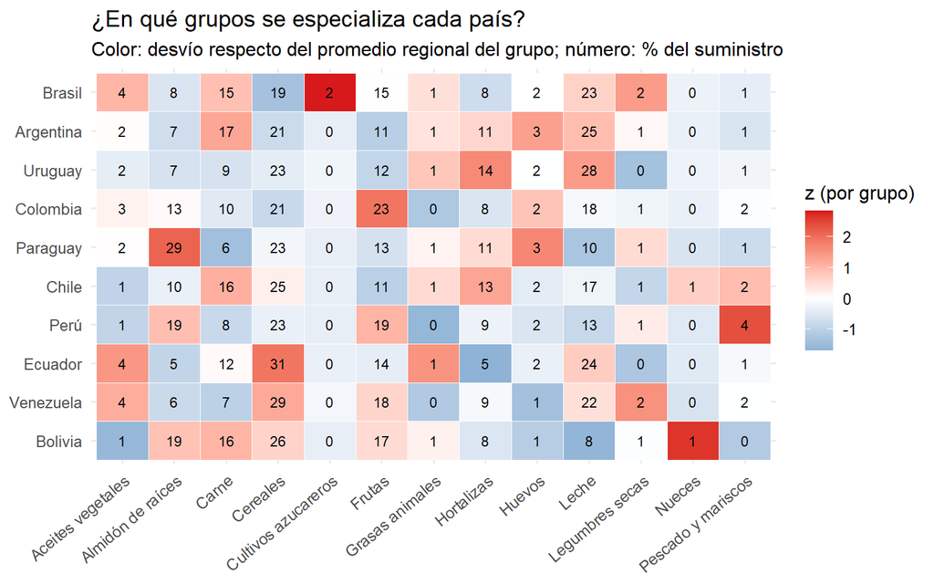

```r
comp_long |>
  group_by(grupo) |> mutate(z = as.numeric(scale(pct))) |> ungroup() |>
  ggplot(aes(grupo, factor(pais, levels = rev(orden_pais)), fill = z)) +
  geom_tile(color = "white") +
  geom_text(aes(label = round(pct, 0)), size = 3) +
  scale_fill_gradient2(low = "#2b83ba", mid = "white", high = "#d7191c", name = "z (por grupo)") +
  labs(title = "¿En qué grupos se especializa cada país?",
       subtitle = "Color: desvío respecto del promedio regional del grupo; número: % del suministro",
       x = NULL, y = NULL) +
  theme(axis.text.x = element_text(angle = 40, hjust = 1))
```

```r
kpis |> transmute(pais, `Frutas y hortalizas (g/día)` = frutas_hortalizas_g_dia,
                  `Score frutas y hortalizas` = score_frutas_verduras,
                  `Energía de grasa (%)` = pct_energia_grasa, `Score grasa` = score_grasa,
                  `Índice de calidad parcial` = indice_calidad_oferta_parcial) |>
  arrange(desc(`Índice de calidad parcial`)) |>
  kable(digits = 1, caption = "Componentes del índice de calidad por país")
```

Componentes del índice de calidad por país

| pais | Frutas y hortalizas (g/día) | Score frutas y hortalizas | Energía de grasa (%) | Score grasa | Índice de calidad parcial |
| --- | --- | --- | --- | --- | --- |
| Colombia | 543.5 | 100.0 | 29.6 | 100.0 | 100.0 |
| Paraguay | 420.7 | 100.0 | 26.8 | 100.0 | 100.0 |
| Perú | 528.2 | 100.0 | 21.4 | 100.0 | 100.0 |
| Chile | 390.8 | 97.7 | 27.7 | 100.0 | 98.8 |
| Bolivia | 356.7 | 89.2 | 22.1 | 100.0 | 94.6 |
| Venezuela | 376.4 | 94.1 | 31.5 | 92.5 | 93.3 |
| Uruguay | 536.3 | 100.0 | 32.9 | 85.5 | 92.8 |
| Argentina | 420.9 | 100.0 | 36.4 | 68.0 | 84.0 |
| Brasil | 422.4 | 100.0 | 37.1 | 64.5 | 82.2 |
| Ecuador | 232.9 | 58.2 | 35.1 | 74.5 | 66.4 |

El país de menor calidad parcial, Ecuador, lo es sobre todo por el déficit de frutas y hortalizas (233 g/día de frutas y hortalizas y 35.1 % de energía de grasa). Brasil, el país más diverso, tiene una calidad parcial de 82.2 con 37.1 % de energía de grasa: diversidad y calidad miden aspectos distintos (cuántos grupos y cómo se reparten, frente a la cercanía a dos umbrales de la OMS).

## 5.3 Perfil comercial

```r
com_pais <- panel_vent |> group_by(pais) |>
  summarise(autosuficiencia = mean(ratio_autosuficiencia),
            dependencia_importaciones = mean(ratio_dependencia_importaciones),
            orientacion_exportadora = mean(ratio_orientacion_exportadora), .groups = "drop") |>
  arrange(desc(autosuficiencia))
kable(com_pais, digits = 2, caption = paste0("Razones comerciales promedio ", vent_txt))
```

Razones comerciales promedio 2019-2023

| pais | autosuficiencia | dependencia_importaciones | orientacion_exportadora |
| --- | --- | --- | --- |
| Argentina | 1.78 | 0.02 | 0.43 |
| Uruguay | 1.38 | 0.34 | 0.52 |
| Ecuador | 1.34 | 0.14 | 0.35 |
| Paraguay | 1.30 | 0.04 | 0.30 |
| Brasil | 1.05 | 0.02 | 0.06 |
| Bolivia | 1.01 | 0.04 | 0.05 |
| Perú | 1.00 | 0.20 | 0.20 |
| Chile | 1.00 | 0.39 | 0.39 |
| Colombia | 0.89 | 0.16 | 0.05 |
| Venezuela | 0.79 | 0.22 | 0.00 |

Argentina es el país más autosuficiente (1.78) y Venezuela el menos (0.79). La mayor dependencia de importaciones corresponde a Chile (0.39) y la mayor orientación exportadora a Uruguay (0.52). 3 de los 10 países producen menos de lo que ofertan internamente (autosuficiencia menor que 1) en la ventana.

# 6 Evolución temporal 2010-2023

En esta sección, “promedio regional” es la media simple de los 10 países (sin ponderar por población).

```r
vars_t <- c("kcal_dia_total", "food_diversity_index", "indice_calidad_oferta",
            "ratio_dependencia_importaciones", "ratio_autosuficiencia", "ratio_orientacion_exportadora")
et_t <- c("Energía (kcal/día)", "Índice de diversidad", "Índice de calidad",
          "Dependencia de importaciones", "Autosuficiencia", "Orientación exportadora")
regional <- panel |> group_by(ano) |> summarise(across(all_of(vars_t), mean), .groups = "drop")
regional_sv <- panel |> filter(pais != "Venezuela") |> group_by(ano) |> summarise(kcal_sv = mean(kcal_dia_total), .groups = "drop")
```

## 6.1 Energía disponible

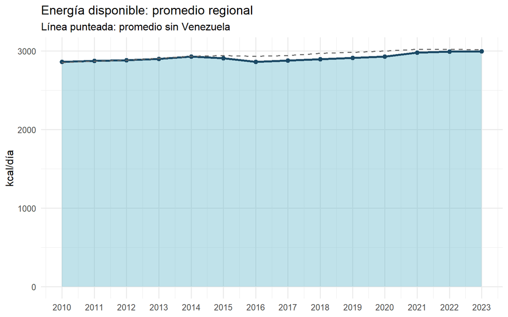

```r
ggplot(regional, aes(ano, kcal_dia_total)) +
  geom_area(fill = "#62B6CB", alpha = 0.4) +
  geom_line(color = "#1B4965", linewidth = 1.2) + geom_point(color = "#1B4965", size = 2) +
  geom_line(data = regional_sv, aes(y = kcal_sv), color = "grey40", linetype = "dashed") +
  scale_x_continuous(breaks = anios) +
  labs(title = "Energía disponible: promedio regional",
       subtitle = "Línea punteada: promedio sin Venezuela",
       x = NULL, y = "kcal/día")
```

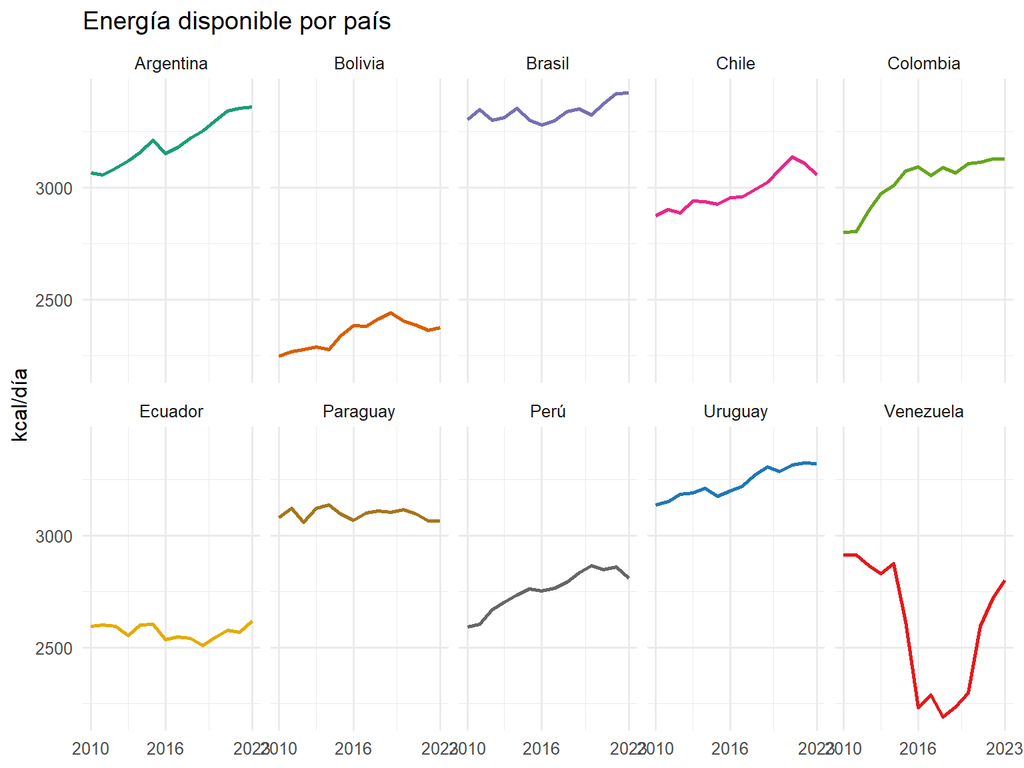

```r
ggplot(panel, aes(ano, kcal_dia_total, color = pais)) +
  geom_line(linewidth = 1, show.legend = FALSE) +
  scale_color_manual(values = paleta_paises) +
  facet_wrap(~pais, ncol = 5) +
  scale_x_continuous(breaks = c(2010, 2016, 2023)) +
  labs(title = "Energía disponible por país", x = NULL, y = "kcal/día")
```

El promedio regional pasó de 2 861 kcal/día en 2010 a 2 996 en 2023. La trayectoria no es monótona: tras un máximo temporal en 2014 (2 930) el promedio desciende hasta 2 865 en 2016 (-65 kcal). Sin Venezuela esa variación sería de -0.4 kcal, es decir, el descenso regional se debe en gran parte a un solo país. En Venezuela la energía disponible fue de 2 916 kcal/día como máximo y de 2 190 en 2018 (-25 %), con una recuperación posterior hasta 2 800 en 2023.

## 6.2 Diversidad y calidad

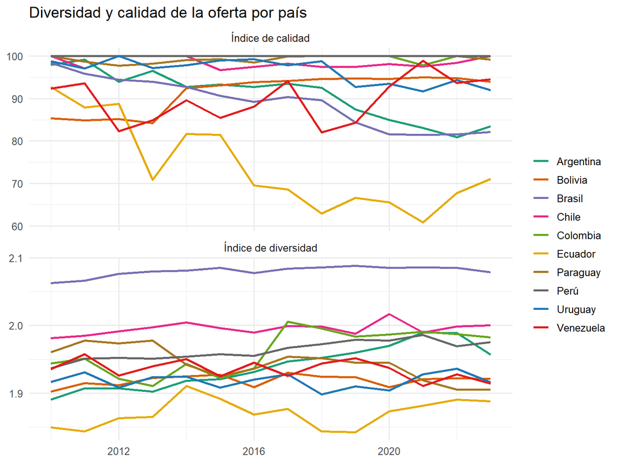

```r
panel |> select(pais, ano, food_diversity_index, indice_calidad_oferta) |>
  pivot_longer(c(food_diversity_index, indice_calidad_oferta)) |>
  mutate(name = recode(name, food_diversity_index = "Índice de diversidad", indice_calidad_oferta = "Índice de calidad")) |>
  ggplot(aes(ano, value, color = pais)) +
  geom_line(linewidth = 0.9) +
  scale_color_manual(values = paleta_paises) +
  facet_wrap(~name, scales = "free_y", ncol = 1) +
  labs(title = "Diversidad y calidad de la oferta por país", x = NULL, y = NULL, color = NULL)
```

## 6.3 Comercio exterior: autosuficiencia, dependencia y orientación exportadora

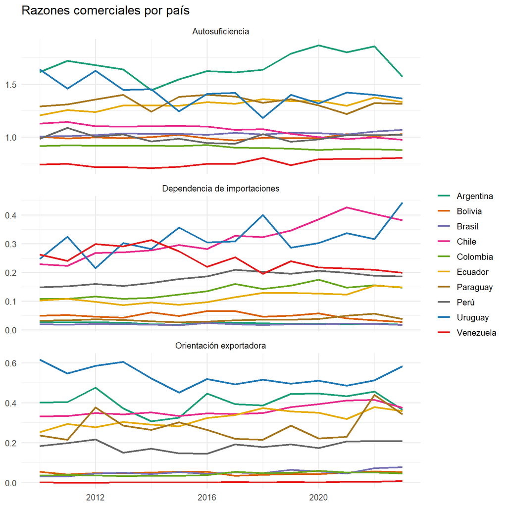

```r
panel |> select(pais, ano, ratio_autosuficiencia, ratio_dependencia_importaciones, ratio_orientacion_exportadora) |>
  pivot_longer(-c(pais, ano)) |>
  mutate(name = recode(name, ratio_autosuficiencia = "Autosuficiencia",
                       ratio_dependencia_importaciones = "Dependencia de importaciones",
                       ratio_orientacion_exportadora = "Orientación exportadora")) |>
  ggplot(aes(ano, value, color = pais)) +
  geom_line(linewidth = 0.9) +
  scale_color_manual(values = paleta_paises) +
  facet_wrap(~name, scales = "free_y", ncol = 1) +
  labs(title = "Razones comerciales por país", x = NULL, y = NULL, color = NULL)
```

## 6.4 Cambio descriptivo entre el inicio y el final del período

Se comparan los promedios de 2010-2013 y 2020-2023 para suavizar la variación anual.

```r
ini <- min(anios):(min(anios) + 3); fin <- (max(anios) - 3):max(anios)
cambio <- panel |> group_by(pais) |>
  summarise(kcal_inicio = mean(kcal_dia_total[ano %in% ini]), kcal_final = mean(kcal_dia_total[ano %in% fin]),
            div_inicio = mean(food_diversity_index[ano %in% ini]), div_final = mean(food_diversity_index[ano %in% fin]),
            dep_inicio = mean(ratio_dependencia_importaciones[ano %in% ini]),
            dep_final = mean(ratio_dependencia_importaciones[ano %in% fin]), .groups = "drop") |>
  mutate(kcal_cambio_pct = 100 * (kcal_final / kcal_inicio - 1),
         div_cambio = div_final - div_inicio,
         dep_cambio_pp = 100 * (dep_final - dep_inicio))
cambio |> select(pais, kcal_inicio, kcal_final, kcal_cambio_pct, div_inicio, div_final, div_cambio, dep_cambio_pp) |>
  arrange(desc(kcal_cambio_pct)) |>
  kable(digits = c(0, 0, 0, 1, 3, 3, 3, 1),
        col.names = c("País", "kcal inicio", "kcal final", "Cambio kcal (%)", "Div. inicio", "Div. final", "Cambio div.", "Cambio dependencia (pp)"),
        caption = "Cambio entre el inicio y el final del período")
```

Cambio entre el inicio y el final del período

| País | kcal inicio | kcal final | Cambio kcal (%) | Div. inicio | Div. final | Cambio div. | Cambio dependencia (pp) |
| --- | --- | --- | --- | --- | --- | --- | --- |
| Colombia | 2869 | 3118 | 8.7 | 1.932 | 1.987 | 0.055 | 4.6 |
| Argentina | 3081 | 3339 | 8.4 | 1.901 | 1.976 | 0.075 | -0.6 |
| Perú | 2643 | 2846 | 7.7 | 1.948 | 1.977 | 0.030 | 4.1 |
| Chile | 2901 | 3096 | 6.7 | 1.989 | 2.001 | 0.012 | 15.2 |
| Bolivia | 2270 | 2382 | 5.0 | 1.913 | 1.918 | 0.005 | -0.7 |
| Uruguay | 3166 | 3313 | 4.6 | 1.920 | 1.921 | 0.001 | 7.8 |
| Brasil | 3316 | 3385 | 2.1 | 2.071 | 2.084 | 0.013 | 0.0 |
| Ecuador | 2586 | 2579 | -0.3 | 1.855 | 1.883 | 0.028 | 3.9 |
| Paraguay | 3096 | 3087 | -0.3 | 1.972 | 1.918 | -0.054 | 1.1 |
| Venezuela | 2882 | 2604 | -9.6 | 1.940 | 1.922 | -0.017 | -6.3 |

La mayor variación de energía es la de Colombia (+8.7 %) y la menor la de Venezuela (-9.6 %). En dependencia de importaciones, Chile registra el mayor aumento (+15.2 pp) y Venezuela la mayor disminución (-6.3 pp). La diversidad cambia como máximo 0.075 puntos del índice en cualquier país, una variación pequeña frente a las diferencias entre países.

## 6.5 Tendencias monótonas (Mann-Kendall)

Como test descriptivo de tendencia se usa la correlación de Kendall entre la variable y el año (equivalente a Mann-Kendall sin corrección por autocorrelación), junto con la pendiente anual (MCO) como medida de magnitud. Para cada variable, los valores p de los 10 países se ajustan con Holm. Con series de 14 puntos y autocorrelación positiva, los valores p tienden a ser optimistas: se interpretan como orientativos.

```r
mk <- function(t, x) {
  if (sd(x) == 0) return(c(tau = 0, p = 1))
  ct <- suppressWarnings(cor.test(t, x, method = "kendall", exact = FALSE))
  c(tau = unname(ct$estimate), p = ct$p.value)
}
mk_paises <- map_dfr(vars_t, function(v) {
  panel |> group_by(pais) |>
    summarise(tau = mk(ano, .data[[v]])["tau"], p = mk(ano, .data[[v]])["p"],
              pendiente = cov(ano, .data[[v]]) / var(ano), .groups = "drop") |>
    mutate(variable = v, p_holm = p.adjust(p, "holm"))
})
mk_reg <- map_dfr(vars_t, function(v) {
  r <- mk(regional$ano, regional[[v]])
  tibble(variable = v, tau = r["tau"], p = r["p"], pendiente = cov(regional$ano, regional[[v]]) / var(regional$ano))
})
mk_res <- mk_reg |>
  left_join(mk_paises |> group_by(variable) |>
              summarise(paises_suben = sum(p_holm < 0.05 & tau > 0), paises_bajan = sum(p_holm < 0.05 & tau < 0), .groups = "drop"),
            by = "variable") |>
  mutate(variable = et_t[match(variable, vars_t)])
kable(mk_res, digits = c(0, 3, 4, 4, 0, 0),
      col.names = c("Variable", "tau (regional)", "p (regional)", "Pendiente anual (regional)", "Países con alza (Holm)", "Países con baja (Holm)"),
      caption = "Tendencia del promedio regional y número de países con tendencia significativa tras Holm")
```

Tendencia del promedio regional y número de países con tendencia significativa tras Holm

| Variable | tau (regional) | p (regional) | Pendiente anual (regional) | Países con alza (Holm) | Países con baja (Holm) |
| --- | --- | --- | --- | --- | --- |
| Energía (kcal/día) | 0.692 | 0.0006 | 8.7330 | 6 | 0 |
| Índice de diversidad | 0.538 | 0.0073 | 0.0014 | 2 | 1 |
| Índice de calidad | -0.692 | 0.0006 | -0.3914 | 1 | 3 |
| Dependencia de importaciones | 0.890 | 0.0000 | 0.0029 | 3 | 2 |
| Autosuficiencia | -0.099 | 0.6222 | -0.0003 | 2 | 2 |
| Orientación exportadora | 0.407 | 0.0428 | 0.0021 | 4 | 0 |

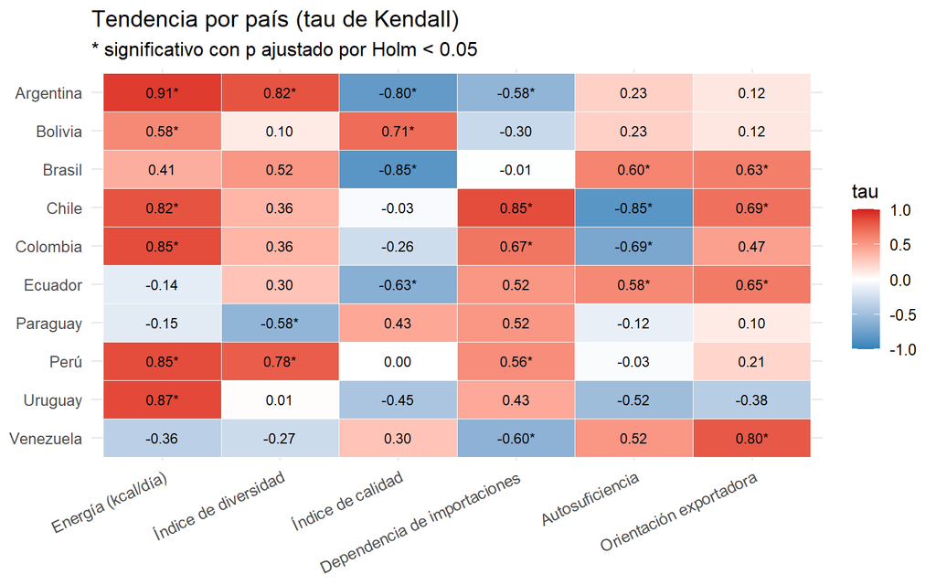

```r
mk_paises |>
  mutate(variable = factor(variable, levels = vars_t, labels = et_t),
         etiqueta = paste0(f2(tau, 2), ifelse(p_holm < 0.05, "*", ""))) |>
  ggplot(aes(variable, factor(pais, levels = rev(sort(unique(pais)))), fill = tau)) +
  geom_tile(color = "white") + geom_text(aes(label = etiqueta), size = 3) +
  scale_fill_gradient2(low = "#2b83ba", mid = "white", high = "#d7191c", limits = c(-1, 1), name = "tau") +
  labs(title = "Tendencia por país (tau de Kendall)", subtitle = "* significativo con p ajustado por Holm < 0.05", x = NULL, y = NULL) +
  theme(axis.text.x = element_text(angle = 25, hjust = 1))
```

- **Energía.** El promedio regional muestra una tendencia ascendente significativa (tau = 0.69, p = < 0.001, pendiente 8.7 kcal/día por año); 6 países con alza y 0 países con baja significativos tras Holm. La trayectoria regional incluye el descenso descrito arriba, por lo que hablar de un ascenso sostenido no describe adecuadamente todo el período.
- **Diversidad.** Tendencia regional: tau = 0.54 (p = 0.007); 2 países con alza y 1 país con baja significativos tras Holm.
- **Dependencia de importaciones.** Tendencia regional: tau = 0.89 (p = < 0.001); 3 países con alza y 2 países con baja significativos tras Holm.
- **Calidad y autosuficiencia.** Calidad: tau regional de -0.69 (p = < 0.001; 1 país con alza y 3 países con baja significativos tras Holm). Autosuficiencia: tau regional de -0.10 (p = 0.622).

## 6.6 Anomalías de comercio exterior: Venezuela y Brasil

```r
ven_tab <- exp_ven |> select(Año = ano, Exportaciones = exportaciones_total, Importaciones = importaciones_total,
                             Producción = produccion_total, `kcal/día` = kcal_dia_total)
kable(ven_tab, digits = 0, caption = "Venezuela: comercio exterior, producción y energía por año")
```

Venezuela: comercio exterior, producción y energía por año

| Año | Exportaciones | Importaciones | Producción | kcal/día |
| --- | --- | --- | --- | --- |
| 2010 | 27 | 7391 | 20916 | 2916 |
| 2011 | 15 | 6809 | 21258 | 2914 |
| 2012 | 16 | 8455 | 20331 | 2866 |
| 2013 | 24 | 8326 | 20510 | 2831 |
| 2014 | 22 | 8961 | 20328 | 2876 |
| 2015 | 29 | 6977 | 18411 | 2616 |
| 2016 | 28 | 4637 | 15819 | 2231 |
| 2017 | 43 | 5325 | 15735 | 2289 |
| 2018 | 31 | 4049 | 16721 | 2190 |
| 2019 | 36 | 4622 | 14201 | 2235 |
| 2020 | 37 | 4333 | 15792 | 2299 |
| 2021 | 76 | 4895 | 18195 | 2596 |
| 2022 | 80 | 4747 | 18151 | 2721 |
| 2023 | 144 | 4695 | 19080 | 2800 |

```r
ven_cambio <- exp_ven |>
  summarise(imp_i = mean(importaciones_total[ano %in% ini]), imp_f = mean(importaciones_total[ano %in% fin]),
            exp_i = mean(exportaciones_total[ano %in% ini]), exp_f = mean(exportaciones_total[ano %in% fin]),
            prod_i = mean(produccion_total[ano %in% ini]), prod_f = mean(produccion_total[ano %in% fin]),
            dep_i = mean(ratio_dependencia_importaciones[ano %in% ini]), dep_f = mean(ratio_dependencia_importaciones[ano %in% fin]))
v_imp <- 100 * (ven_cambio$imp_f / ven_cambio$imp_i - 1)
v_exp <- 100 * (ven_cambio$exp_f / ven_cambio$exp_i - 1)
v_prod <- 100 * (ven_cambio$prod_f / ven_cambio$prod_i - 1)
v_dep <- 100 * (ven_cambio$dep_f - ven_cambio$dep_i)
```

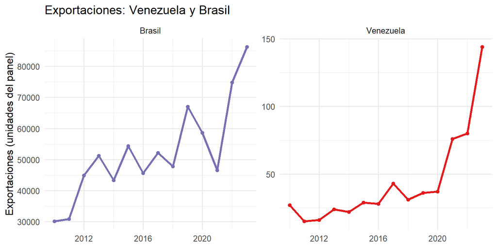

```r
panel |> filter(pais %in% c("Venezuela", "Brasil")) |>
  ggplot(aes(ano, exportaciones_total, color = pais)) +
  geom_line(linewidth = 1.1) + geom_point() +
  scale_color_manual(values = paleta_paises, guide = "none") +
  facet_wrap(~pais, scales = "free_y") +
  labs(title = "Exportaciones: Venezuela y Brasil", x = NULL, y = "Exportaciones (unidades del panel)")
```

**Venezuela.** Comparando 2010-2013 con 2020-2023, las importaciones disminuyeron 40 %, la producción disminuyó 14 % y las exportaciones aumentaron 311 %. Las exportaciones crecen a pesar de que el comercio de entrada y la producción se contraen, por lo que no se trata de una contracción del comercio en ambos sentidos. Dado su pequeño nivel de partida (entre 15 y 43 hasta 2020), el aumento a 76, 80 y 144 puede reflejar cambios en la composición de lo exportado o en el registro estadístico; los datos no permiten distinguirlo. La dependencia de importaciones de Venezuela varía -6.3 pp: su descenso acompaña a la caída de las importaciones (y de la producción) y no indica un avance hacia la autosuficiencia.

**Brasil.** Hasta 2022 el máximo de sus exportaciones fue 74 773; en 2023 alcanza 86 240, 1.15 veces el máximo previo. Es el segundo caso de comportamiento atípico dentro de la propia serie.

# 7 Relaciones bivariadas exploratorias

Con n = 10 países, un coeficiente de correlación debe superar |r| = 0.63 para ser significativo al 5 % de forma individual, y cuando se calculan muchas correlaciones esa exigencia aumenta. Todo lo que sigue es **exploratorio**: describe cómo co-varían las variables en esta muestra, no evidencia confirmatoria.

## 7.1 Matriz de correlación (nivel país, ventana 2019-2023)

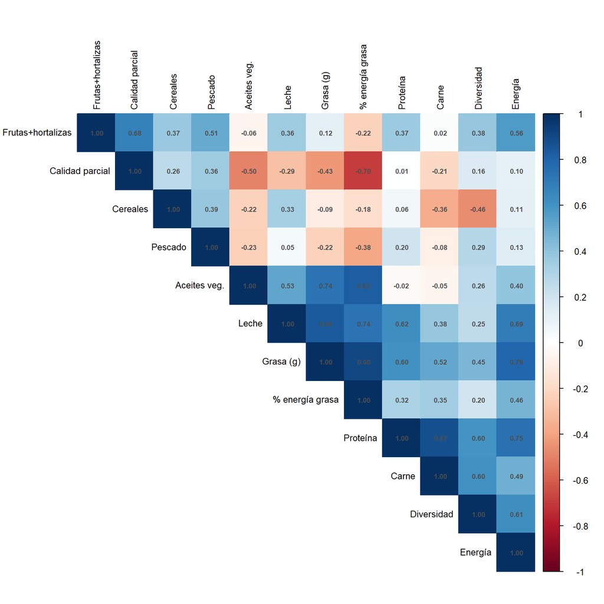

```r
vars_cor <- c("food_diversity_index", "kcal_persona_dia_total", "proteina_g_persona_dia_total",
              "grasa_g_persona_dia_total", "pct_energia_grasa", "frutas_hortalizas_g_dia",
              "indice_calidad_oferta_parcial", "carne", "cereales_exc_cerveza", "leche_excl_mantequilla",
              "aceites_vegetales", "pescado_y_frutos_de_mar")
et_cor <- c("Diversidad", "Energía", "Proteína", "Grasa (g)", "% energía grasa", "Frutas+hortalizas",
            "Calidad parcial", "Carne", "Cereales", "Leche", "Aceites veg.", "Pescado")
mat_cor <- cor(kpis[vars_cor]); dimnames(mat_cor) <- list(et_cor, et_cor)
corrplot(mat_cor, method = "color", type = "upper", order = "hclust", tl.col = "black", tl.cex = 0.8,
         addCoef.col = "grey30", number.cex = 0.6, mar = c(0, 0, 1, 0))
```

```r
pares <- as.data.frame(as.table(mat_cor)) |>
  filter(as.character(Var1) < as.character(Var2)) |>
  transmute(variable_1 = Var1, variable_2 = Var2, r = Freq) |>
  arrange(desc(abs(r)))
kable(head(pares, 8), digits = 2, caption = "Pares de variables más correlacionados (nivel país)")
```

Pares de variables más correlacionados (nivel país)

| variable_1 | variable_2 | r |
| --- | --- | --- |
| % energía grasa | Grasa (g) | 0.90 |
| Carne | Proteína | 0.87 |
| Grasa (g) | Leche | 0.84 |
| % energía grasa | Aceites veg. | 0.83 |
| Energía | Grasa (g) | 0.79 |
| Energía | Proteína | 0.75 |
| % energía grasa | Leche | 0.74 |
| Aceites veg. | Grasa (g) | 0.74 |

```r
r_div_max <- pares |> filter(variable_1 == "Diversidad" | variable_2 == "Diversidad") |> slice(1)
r_fat <- mat_cor["Grasa (g)", "% energía grasa"]
```

Los pares más correlacionados son, en buena medida, relaciones mecánicas entre indicadores de la misma familia (por ejemplo, gramos de grasa y porcentaje de energía de grasa, r = 0.90). La correlación más alta de la diversidad con cualquier otra variable de la matriz es r = 0.61 (con Energía), frente a r = 0.90 del par más correlacionado.

## 7.2 Diversidad frente a nutrientes y calidad

```r
vars_nutr <- c("kcal_persona_dia_total", "proteina_g_persona_dia_total", "grasa_g_persona_dia_total",
               "pct_energia_grasa", "frutas_hortalizas_g_dia", "indice_calidad_oferta_parcial")
et_nutr <- c("Energía", "Proteína", "Grasa (g)", "% energía grasa", "Frutas+hortalizas", "Calidad parcial")
kpis_sin_br <- filter(kpis, pais != "Brasil")

tab_dn <- map_dfr(seq_along(vars_nutr), function(i) {
  v <- vars_nutr[i]
  ct <- cor.test(kpis$food_diversity_index, kpis[[v]])
  cs <- suppressWarnings(cor.test(kpis$food_diversity_index, kpis[[v]], method = "spearman"))
  cb <- cor.test(kpis_sin_br$food_diversity_index, kpis_sin_br[[v]])
  tibble(variable = et_nutr[i], r_pearson = unname(ct$estimate), p = ct$p.value,
         rho_spearman = unname(cs$estimate), r_sin_brasil = unname(cb$estimate))
}) |> mutate(p_holm = p.adjust(p, "holm"))
kable(tab_dn, digits = 3, caption = "Correlación de la diversidad con nutrientes y calidad (n = 10; p ajustado con Holm)")
```

Correlación de la diversidad con nutrientes y calidad (n = 10; p ajustado con Holm)

| variable | r_pearson | p | rho_spearman | r_sin_brasil | p_holm |
| --- | --- | --- | --- | --- | --- |
| Energía | 0.614 | 0.059 | 0.527 | 0.513 | 0.354 |
| Proteína | 0.600 | 0.067 | 0.600 | 0.597 | 0.354 |
| Grasa (g) | 0.455 | 0.187 | 0.358 | 0.093 | 0.747 |
| % energía grasa | 0.200 | 0.580 | 0.115 | -0.235 | 1.000 |
| Frutas+hortalizas | 0.381 | 0.277 | 0.515 | 0.588 | 0.832 |
| Calidad parcial | 0.159 | 0.662 | 0.239 | 0.612 | 1.000 |

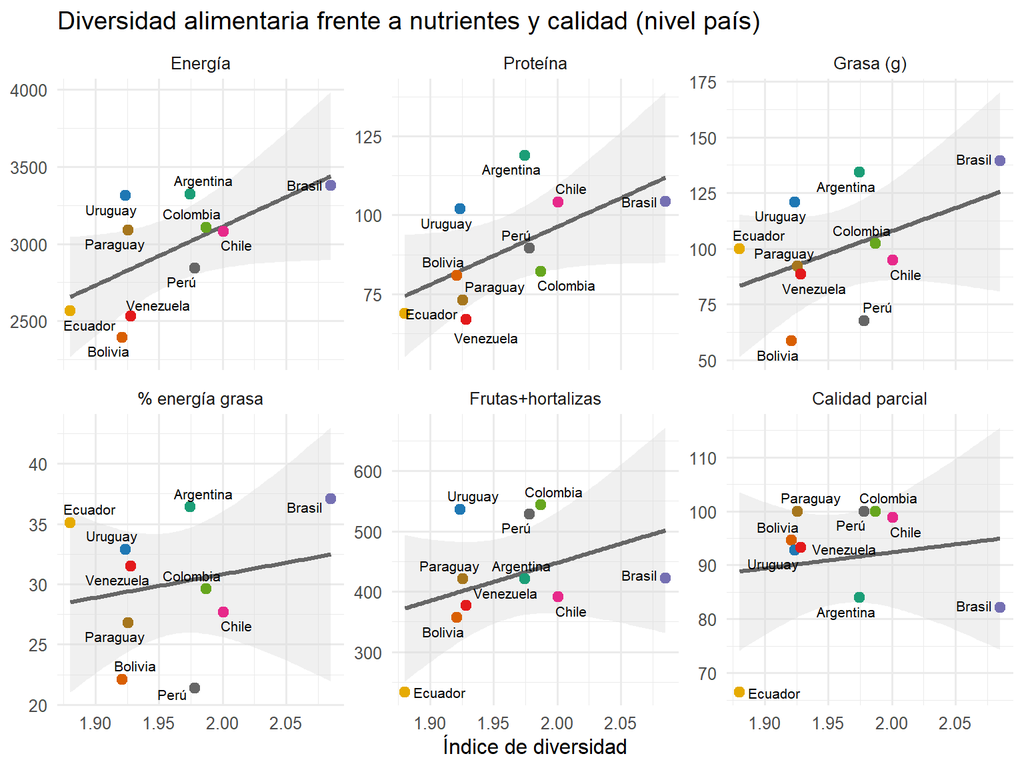

```r
kpis |> select(pais, food_diversity_index, all_of(vars_nutr)) |>
  pivot_longer(-c(pais, food_diversity_index)) |>
  mutate(name = factor(name, levels = vars_nutr, labels = et_nutr)) |>
  ggplot(aes(food_diversity_index, value)) +
  geom_smooth(method = "lm", se = TRUE, color = "grey40", fill = "grey85") +
  geom_point(aes(color = pais), size = 2.5) +
  geom_text_repel(aes(label = pais), size = 2.8, max.overlaps = 20) +
  scale_color_manual(values = paleta_paises, guide = "none") +
  facet_wrap(~name, scales = "free_y") +
  labs(title = "Diversidad alimentaria frente a nutrientes y calidad (nivel país)", x = "Índice de diversidad", y = NULL)
```

0 de las 6 correlaciones son significativas al 5 % sin corrección y 0 tras Holm. La más intensa es la de la diversidad con **energía** (r = 0.61; 0.51 al excluir a Brasil). Ninguna asociación a nivel país resiste la corrección por comparaciones múltiples, lo que es esperable con 10 observaciones y un índice que varía poco; la ausencia de significancia no equivale a ausencia de relación. Como Brasil es a la vez el país más diverso y un caso extremo, conviene mirar la columna sin ese país.

## 7.3 Entre países y dentro de cada país

Una correlación calculada sobre el panel completo mezcla la **diferencia entre países** con la **variación de un mismo país en el tiempo**. Para separarlas se correlacionan (a) los promedios por país y (b) los desvíos de cada observación respecto de la media de su propio país.

```r
resultados <- c("kcal_dia_total", "grasa_g_dia_total", "indice_calidad_oferta")
et_res <- c("Energía", "Grasa (g)", "Índice de calidad")
medias_pais <- panel |> group_by(pais) |> summarise(across(c(food_diversity_index, all_of(resultados)), mean), .groups = "drop")
panel_w <- panel |> group_by(pais) |>
  mutate(across(c(food_diversity_index, all_of(resultados)), ~ .x - mean(.x), .names = "{.col}_w")) |> ungroup()
tab_bw <- map_dfr(seq_along(resultados), function(i) {
  y <- resultados[i]
  tibble(resultado = et_res[i],
         entre_paises = cor(medias_pais$food_diversity_index, medias_pais[[y]]),
         dentro_de_paises = cor(panel_w$food_diversity_index_w, panel_w[[paste0(y, "_w")]]),
         panel_agrupado = cor(panel$food_diversity_index, panel[[y]]))
})
kable(tab_bw, digits = 3, caption = "Correlación con la diversidad: entre países, dentro de países y agrupada")
```

Correlación con la diversidad: entre países, dentro de países y agrupada

| resultado | entre_paises | dentro_de_paises | panel_agrupado |
| --- | --- | --- | --- |
| Energía | 0.558 | 0.298 | 0.529 |
| Grasa (g) | 0.303 | 0.596 | 0.336 |
| Índice de calidad | 0.346 | -0.273 | 0.230 |

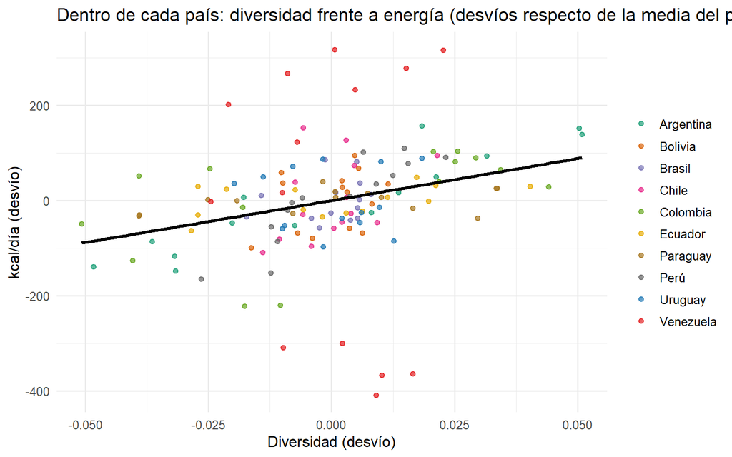

```r
ggplot(panel_w, aes(food_diversity_index_w, kcal_dia_total_w, color = pais)) +
  geom_point(alpha = 0.7) +
  geom_smooth(aes(group = 1), method = "lm", se = FALSE, color = "black") +
  scale_color_manual(values = paleta_paises) +
  labs(title = "Dentro de cada país: diversidad frente a energía (desvíos respecto de la media del país)",
       x = "Diversidad (desvío)", y = "kcal/día (desvío)", color = NULL)
```

Para la energía, la correlación entre países es 0.56, dentro de países 0.30 y agrupada 0.53. Los signos coinciden, aunque las magnitudes difieren; la correlación agrupada mezcla ambas fuentes de variación. Para la calidad, la correlación es 0.35 entre países y -0.27 dentro de países (signos opuestos); para la grasa, 0.30 y 0.60.

# 8 Estructura multivariada exploratoria

Esta sección es breve y es exploratoria: con 10 países y 21 variables (más variables que observaciones) los resultados son inestables.

## 8.1 Análisis de componentes principales

```r
pca_vars <- kpis |> select(where(is.numeric), -food_diversity_index)
pca_res <- prcomp(pca_vars, center = TRUE, scale. = TRUE)
pca_cl_o <- pca_cl[match(kpis$pais, pca_cl$pais), ]
# El signo de un componente es arbitrario: se alinea con el del archivo original para poder comparar
for (j in 1:2) {
  s <- sign(cor(pca_cl_o[[paste0("pc", j)]], pca_res$x[, j]))
  pca_res$x[, j] <- s * pca_res$x[, j]; pca_res$rotation[, j] <- s * pca_res$rotation[, j]
}
rownames(pca_res$x) <- kpis$pais
ve <- 100 * pca_res$sdev^2 / sum(pca_res$sdev^2)
cargas <- as_tibble(pca_res$rotation[, 1:2], rownames = "variable") |>
  mutate(etiqueta = coalesce(unname(etiq_grupos[variable]),
                             recode(variable, kcal_persona_dia_total = "Energía (kcal)", proteina_g_persona_dia_total = "Proteína (g)",
                                    grasa_g_persona_dia_total = "Grasa (g)", frutas_hortalizas_g_dia = "Frutas y hortalizas (g)",
                                    score_frutas_verduras = "Score frutas y verduras", pct_energia_grasa = "% energía de grasa",
                                    score_grasa = "Score grasa", indice_calidad_oferta_parcial = "Índice de calidad parcial"))) |>
  arrange(desc(abs(PC1)))
top4 <- head(cargas$etiqueta, 4)
top4_var <- head(cargas$variable, 4)
eje_calorico <- any(c("kcal_persona_dia_total", "proteina_g_persona_dia_total") %in% top4_var)
cor_pc1 <- abs(cor(pca_cl_o$pc1, pca_res$x[, 1])); cor_pc2 <- abs(cor(pca_cl_o$pc2, pca_res$x[, 2]))
```

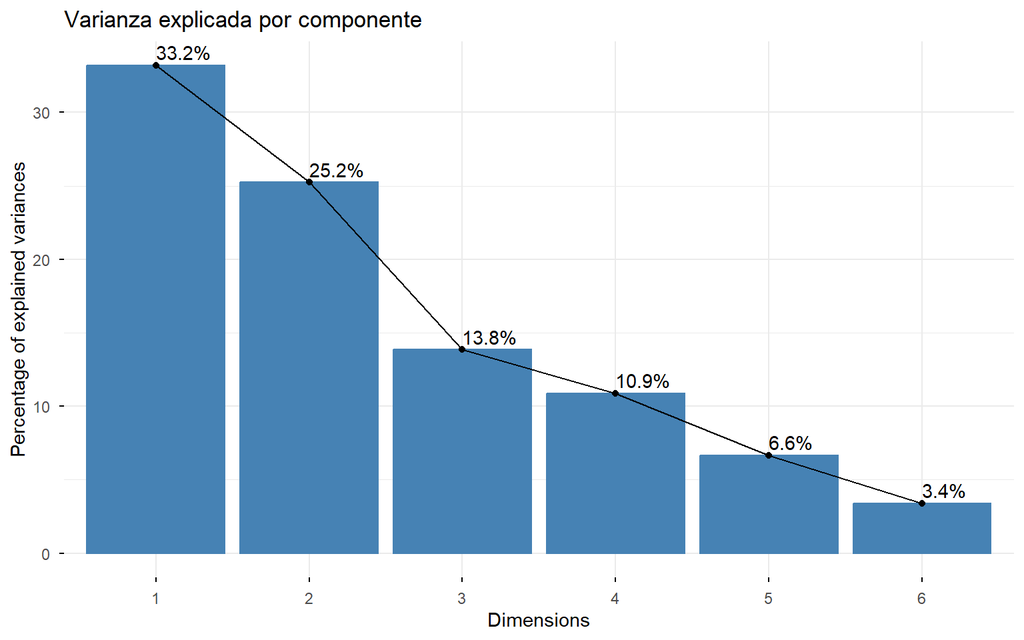

```r
fviz_eig(pca_res, addlabels = TRUE, ncp = 6, main = "Varianza explicada por componente")
```

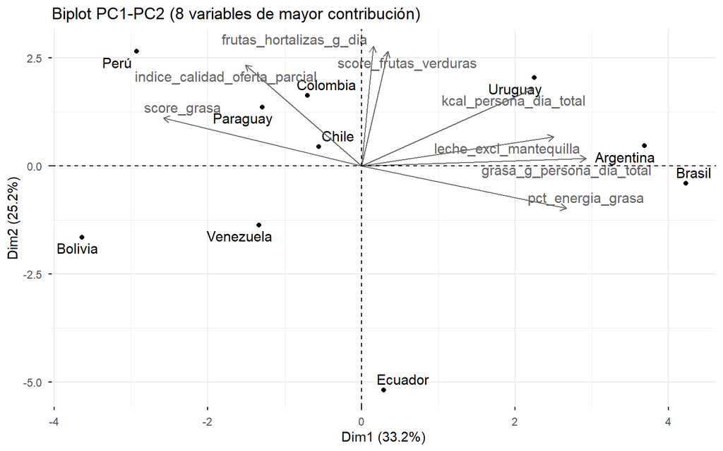

```r
fviz_pca_biplot(pca_res, repel = TRUE, col.var = "grey40", label = "all", select.var = list(contrib = 8),
                title = "Biplot PC1-PC2 (8 variables de mayor contribución)")
```

```r
cargas |> select(Variable = etiqueta, PC1, PC2) |> head(8) |>
  kable(digits = 2, caption = "Mayores cargas en PC1 (ordenadas por valor absoluto)")
```

Mayores cargas en PC1 (ordenadas por valor absoluto)

| Variable | PC1 | PC2 |
| --- | --- | --- |
| Grasa (g) | 0.37 | 0.03 |
| % energía de grasa | 0.34 | -0.14 |
| Score grasa | -0.33 | 0.16 |
| Leche | 0.32 | 0.10 |
| Energía (kcal) | 0.29 | 0.26 |
| Aceites vegetales | 0.26 | -0.08 |
| Grasas animales | 0.25 | -0.07 |
| Proteína (g) | 0.25 | 0.19 |

Los dos primeros componentes explican 33.2 % y 25.2 % de la varianza (58.4 % acumulado). Las variables con mayor peso en PC1 son **Grasa (g), % energía de grasa, Score grasa, Leche**. PC1 no es, por tanto, un eje calórico-proteico: se organiza en torno a la grasa y a la leche, es decir, al perfil graso de la dieta. PC1 separa a Brasil, Argentina, Uruguay (extremo positivo) de Bolivia, Perú, Venezuela (extremo negativo).

Comparación con el archivo `paises_pca_clusters`: la correlación absoluta entre sus componentes y los recalculados aquí es 0.98 en PC1 y 0.24 en PC2. El componente PC2 del archivo no se reproduce con este conjunto de variables, lo que indica que se calculó con otras variables o con un preprocesamiento no documentado; se trata como información auxiliar y no como resultado verificado.

## 8.2 Agrupamiento (clustering) como exploración

```r
d <- dist(scale(pca_vars))
cl_vec <- pca_cl$cluster_kmeans[match(kpis$pais, pca_cl$pais)]
sil <- silhouette(cl_vec, d)
sil_medio <- mean(sil[, "sil_width"])

set.seed(123)
k_tab <- map_dfr(2:6, function(k) {
  km <- kmeans(scale(pca_vars), centers = k, nstart = 25)
  tibble(k = k, silueta_media = mean(silhouette(km$cluster, d)[, "sil_width"]))
})
k_mejor <- k_tab$k[which.max(k_tab$silueta_media)]
k_orig <- n_distinct(cl_vec)

set.seed(123)
km_re <- kmeans(scale(pca_vars), centers = k_orig, nstart = 50)
ari <- function(a, b) {
  tab <- table(a, b); n <- sum(tab); sc <- function(x) sum(choose(x, 2))
  esp <- sc(rowSums(tab)) * sc(colSums(tab)) / choose(n, 2)
  (sc(tab) - esp) / (0.5 * (sc(rowSums(tab)) + sc(colSums(tab))) - esp)
}
ari_km <- ari(cl_vec, km_re$cluster)

perfil_cl <- kpis |> mutate(cluster = cl_vec) |>
  left_join(panel_vent |> group_by(pais) |> summarise(produccion = mean(produccion_total), .groups = "drop"), by = "pais") |>
  group_by(cluster) |>
  summarise(n = n(), paises = paste(pais, collapse = ", "), kcal = mean(kcal_persona_dia_total),
            diversidad = mean(food_diversity_index), calidad = mean(indice_calidad_oferta_parcial),
            produccion_media = mean(produccion), .groups = "drop")
cl_min_prod <- perfil_cl$cluster[which.min(perfil_cl$produccion_media)]
cl_max_prod <- perfil_cl$cluster[which.max(perfil_cl$produccion_media)]
kable(perfil_cl, digits = c(0, 0, 0, 0, 3, 1, 0), caption = paste0("Perfil de los clústeres originales (promedio de los países, ventana ", vent_txt, ")"))
```

Perfil de los clústeres originales (promedio de los países, ventana 2019-2023)

| cluster | n | paises | kcal | diversidad | calidad | produccion_media |
| --- | --- | --- | --- | --- | --- | --- |
| 0 | 3 | Argentina, Brasil, Uruguay | 3337 | 1.994 | 86.3 | 397203 |
| 1 | 3 | Bolivia, Chile, Ecuador | 2680 | 1.934 | 86.6 | 22508 |
| 2 | 4 | Colombia, Paraguay, Perú, Venezuela | 2893 | 1.955 | 98.3 | 37923 |

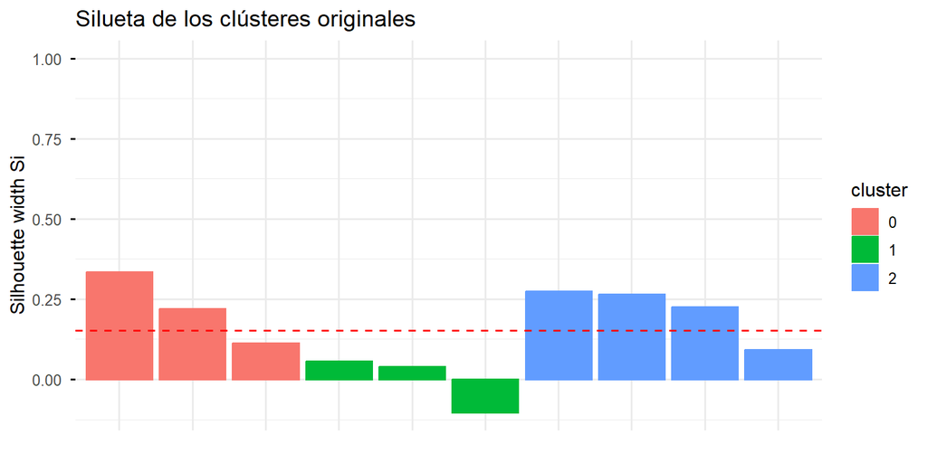

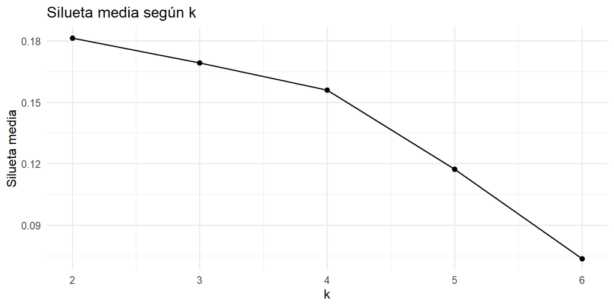

```r
invisible(capture.output(p1 <- fviz_silhouette(sil) + labs(title = "Silueta de los clústeres originales")))
p2 <- ggplot(k_tab, aes(k, silueta_media)) + geom_line() + geom_point(size = 2) +
  labs(title = "Silueta media según k", x = "k", y = "Silueta media")
p1; p2
```

La silueta media de la partición original es 0.15; según Kaufman y Rousseeuw (1990), no hay una estructura sustancial. La silueta media se maximiza con k = 2 (0.18), no con k = 3 (0.17). Al recalcular k-means con k = 3, el índice de Rand ajustado respecto de la partición original es 0.51 (1 = idénticas, 0 = azar). El clúster de **menor** producción media es el **1** (Bolivia, Chile, Ecuador) y el de mayor producción es el 0. Por tanto, el agrupamiento se emplea solo como una tipología orientativa y no se utiliza en los análisis posteriores.

# 9 Síntesis de hallazgos descriptivos

1. **Calidad de los datos.** Se superan 10 de 13 controles automáticos. No hay valores faltantes ni duplicados y el panel está completo. Los controles que no se cumplen son: «Composición por grupo de los KPIs = promedio de esa ventana (tolerancia 1e-6)»; «Índice de diversidad de los KPIs = promedio anual del índice del panel en la ventana (tolerancia 1e-3)»; «Clúster del panel coincide con Cluster_KMeans». Los resultados por país describen 2019-2023; el índice de diversidad de los KPIs es el Shannon de la composición promedio y no el promedio de los índices anuales; la columna `cluster` del panel se excluyó.
2. **Brechas entre países.** La energía disponible varía 41 % entre Bolivia y Brasil. La diversidad es casi homogénea salvo por Brasil.
3. **Diversidad y calidad son dimensiones distintas.** La calidad parcial depende de la grasa y de las frutas y hortalizas; el país más diverso no es el de mayor calidad.
4. **Evolución.** La energía regional tiene una tendencia ascendente significativa (tau = 0.69), con un tramo de descenso hasta 2016 en buena parte explicado por Venezuela. La dependencia de importaciones regional tiene tau = 0.89 (p = < 0.001).
5. **Venezuela.** Entre los extremos del período sus exportaciones aumentaron 311 %, mientras que sus importaciones disminuyeron 40 % y su producción disminuyó 14 %. Brasil muestra un salto exportador en 2023.
6. **Relaciones exploratorias.** A nivel país, 0 de 6 correlaciones de la diversidad resisten la corrección de Holm. Entre países y dentro de países, la relación diversidad-energía tiene correlaciones de 0.56 y 0.30.
7. **Estructura multivariada.** PC1 explica 33.2 % de la varianza y se asocia con Grasa (g), % energía de grasa, Score grasa, Leche; el agrupamiento original tiene silueta media 0.15 (no hay una estructura sustancial).

# 10 Siguiente etapa: ¿análisis diagnóstico o predictivo?

## 10.1 Diferencia entre ambos enfoques

|  | **Diagnóstico (explicativo)** | **Predictivo** |
| --- | --- | --- |
| Pregunta | ¿Por qué difieren los países o cambia su oferta? ¿Qué factores se asocian con la diversidad o la energía? | ¿Qué valores tomarán la energía, la diversidad o la dependencia en los próximos años? |
| Criterio de éxito | Estimaciones interpretables, con incertidumbre válida | Error de pronóstico fuera de muestra |
| Validación | Diagnósticos del modelo, robustez de los errores estándar | Validación **temporal** (entrenar en el pasado, evaluar en el futuro) |
| Exigencia de los datos | Variación suficiente entre y dentro de unidades | Series largas, regularidad y pocos cambios estructurales |

## 10.2 Factibilidad con estos datos

```r
n_obs <- nrow(panel); n_unid <- n_distinct(panel$pais); n_t <- length(anios)

ac1 <- panel |> group_by(pais) |>
  summarise(kcal = cor(kcal_dia_total[-1], kcal_dia_total[-n()]),
            diversidad = cor(food_diversity_index[-1], food_diversity_index[-n()]), .groups = "drop")
ac_med <- c(kcal = mean(ac1$kcal), diversidad = mean(ac1$diversidad))

# Comparación ingenua con partición temporal: entrenar hasta 2020, evaluar 2021-2023
corte <- max(anios) - 3
bench <- panel |> group_by(pais) |>
  summarise(ultimo = kcal_dia_total[ano == corte], media_ent = mean(kcal_dia_total[ano <= corte]),
            real = list(kcal_dia_total[ano > corte]), .groups = "drop") |>
  mutate(mae_persist = map2_dbl(ultimo, real, ~ mean(abs(.y - .x))),
         mae_media = map2_dbl(media_ent, real, ~ mean(abs(.y - .x))))
mae_p <- mean(bench$mae_persist); mae_m <- mean(bench$mae_media)
mae_p_sv <- mean(bench$mae_persist[bench$pais != "Venezuela"]); mae_m_sv <- mean(bench$mae_media[bench$pais != "Venezuela"])
kcal_media_total <- mean(panel$kcal_dia_total)
nivel_ac <- function(r) ifelse(r > 0.7, "alta", ifelse(r > 0.4, "moderada", "baja"))
mejor_ref <- if (mae_p < mae_m) "repetir el último valor observado" else "la media histórica"
peor_ref  <- if (mae_p < mae_m) "la media histórica" else "repetir el último valor observado"
mae_mejor <- min(mae_p, mae_m); mae_peor <- max(mae_p, mae_m)

tibble(criterio = c("Observaciones (países x años)", "Unidades (países)", "Años por unidad",
                    "Autocorrelación de orden 1, energía (promedio por país)",
                    "Autocorrelación de orden 1, diversidad (promedio por país)",
                    paste0("Error absoluto medio en 2021-2023, 'repetir el último valor' (kcal)"),
                    paste0("Error absoluto medio en 2021-2023, 'media histórica' (kcal)")),
       valor = c(n_obs, n_unid, n_t, ac_med[1], ac_med[2], mae_p, mae_m)) |>
  kable(digits = 2, caption = "Indicadores de factibilidad")
```

Indicadores de factibilidad

| criterio | valor |
| --- | --- |
| Observaciones (países x años) | 140.00 |
| Unidades (países) | 10.00 |
| Años por unidad | 14.00 |
| Autocorrelación de orden 1, energía (promedio por país) | 0.74 |
| Autocorrelación de orden 1, diversidad (promedio por país) | 0.42 |
| Error absoluto medio en 2021-2023, ‘repetir el último valor’ (kcal) | 77.50 |
| Error absoluto medio en 2021-2023, ‘media histórica’ (kcal) | 98.80 |

La muestra tiene 140 observaciones, pero solo 10 unidades independientes y 14 períodos por unidad. Las series muestran persistencia alta en energía (autocorrelación media de orden 1 de 0.74) y moderada en diversidad (0.42): las observaciones consecutivas de un mismo país no son independientes y el tamaño efectivo es menor que 140. Esto condiciona ambos caminos:

- **Predictivo.** Al predecir la energía de 2021-2023 con datos hasta 2020, la mejor de las dos referencias ingenuas es repetir el último valor observado (error absoluto medio de 77 kcal/día, 2.7 % de la energía media), frente a 99 kcal/día de la media histórica; una referencia así es difícil de mejorar con 14 puntos por país. Sin Venezuela, cuyo cambio reciente es brusco, los errores son de 41 (último valor) y 95 kcal/día (media). Un modelo de aprendizaje automático clásico con validación cruzada aleatoria **filtraría información del futuro al pasado** (años vecinos del mismo país en entrenamiento y prueba) e inflaría el desempeño; la validación debe ser temporal y, con tan pocos puntos, el riesgo de sobreajuste es alto.
- **Diagnóstico.** Los modelos de panel con efectos de país aprovechan justamente la estructura de pocas unidades y varios períodos, separan lo permanente de cada país de lo que cambia en el tiempo y entregan estimaciones interpretables. Su principal fragilidad es la inferencia con 10 grupos (errores estándar agrupados poco confiables).